# M2.991_20242_PAC3-Enunciat-1

[figure not shown]

M2.991 · Aprenentatge automàtic · PAC3

2024-2 · Màster universitari en Ciència de dades (Data science)

Estudis d'Informàtica, Multimèdia i Telecomunicació

# PEC 3: Mètodes supervisats

En aquesta pràctica veurem diferents mètodes supervisats i mirarem d'optimitzar diferents mètriques. Veurem com els diferents models classifiquen les observacions i amb quins obtenim un rendiment més alt. Després aplicarem tot el que hem après fins ara a un dataset nou simulant un cas pràctic real.

1. Exploració d'algorismes supervisats

   1.1. Càrrega de dades

   1.2. K veïns més propers (KNN)

   1.3. Màquines de vectors de suport (SVM)

   1.4. Arbres de decisió
2. Comprensió d'algorismes supervisats
3. Implementació del cas pràctic

   2.1. Càrrega de dades

   2.2. Anàlisi Exploratòria de Dades

   2.3. Preprocessament de Dades

   2.4. Modelització

Consideracions generals:

- La solució plantejada no pot utilitzar mètodes, funcions o paràmetres declarats *deprecated* en futures versions, a excepció de la càrrega de dades com s'indica posteriorment.
- Aquesta PAC s'ha de realitzar de forma **estrictament individual**. Qualsevol indici de còpia serà penalitzat amb un suspens (D) per a totes les parts implicades i la possible avaluació negativa de l'assignatura de forma íntegra.
- Cal que l'estudiant indiqui **totes les fonts** que ha utilitzat per a la realització de la PAC. En cas contrari, es considerarà que l'estudiant ha comès plagi, i serà penalitzat amb un suspens (D) i la possible avaluació negativa de l'assignatura de forma íntegra.

Format del lliurament:

- Alguns exercicis poden suposar diversos minuts d'execució, per la qual cosa el lliurament s'ha de fer en **format notebook** i en **format html**, on es vegi el codi, els resultats i els comentaris de cada exercici. Es pot exportar el notebook a HTML des del menú File $\to$ Download as $\to$ HTML.
- Hi ha un tipus de cel·la especial per allotjar text. Aquest tipus de cel·la us serà molt útil per respondre a les diferents preguntes teòriques plantejades al llarg de l'activitat. Per canviar el tipus de cel·la a aquest tipus, al menú: Cell $\to$ Cell Type $\to$ Markdown.

**Nom i cognoms: Marc Cervera Rosell**

```python
!pip install kagglehub==0.3.12
```

```python
!pip install umap-learn==0.5.6
```

```python
import os
import tqdm
import kagglehub
import umap

import seaborn as sns
import pandas as pd
import numpy as np
import matplotlib.pyplot as plt

from matplotlib.colors import ListedColormap

from sklearn import datasets
from sklearn import tree
from sklearn.svm import SVC
from sklearn.tree import DecisionTreeClassifier, DecisionTreeRegressor
from sklearn.neighbors import KNeighborsClassifier, KNeighborsRegressor
from sklearn.model_selection import GridSearchCV
from sklearn.metrics import accuracy_score, confusion_matrix, f1_score
from sklearn.preprocessing import StandardScaler
from sklearn.model_selection import StratifiedKFold, train_test_split, cross_val_score

%matplotlib inline
```

# 1. Exploració d'algorismes supervisats (3.75 punts)

## 1.1. Càrrega de dades

L'enfonsament del Titanic és un dels naufragis més tristament cèlebres de la història. El 15 d'abril de 1912, durant el seu viatge inaugural, el considerat «insubmergible» RMS Titanic es va enfonsar després de xocar amb un iceberg. Malauradament, no hi havia suficients bots salvavides per a tots els ocupants, la qual cosa va provocar la mort de 1.502 dels 2.224 passatgers i tripulants. Tot i que hi va haver una mica de sort en la supervivència, sembla que alguns grups de persones van tenir més probabilitats de sobreviure que d'altres.

En aquest exercici treballarem amb el conjunt de dades [Titanic-Dataset](https://www.kaggle.com/datasets/yasserh/titanic-dataset?select=Titanic-Dataset.csv), el qual conté la descripció d'una part dels passatgers i tripulants del Titanic.

El codi següent carregarà les dades dels passatgers i en realitzarà una transformació. De cada passatger tenim informació diversa (conjunt X) com l'edat o la categoria en la qual viatjava, així com la variable objectiu (y), que indica si la persona va sobreviure o no al tràgic accident. Podem comprovar que la càrrega ha estat correcta obtenint les dimensions d'aquests dos conjunts.

```python
root_path = kagglehub.dataset_download("yasserh/titanic-dataset")
dataset_path = os.path.join(root_path, "Titanic-Dataset.csv")
data = pd.read_csv(dataset_path)

data = data.drop(columns=['PassengerId', 'Name', 'Ticket', 'Cabin'])
data = data.dropna()

n_classes = 2
labels = ['No', 'Yes']
categorical_columns = ['Sex', 'Embarked']

cat_df = pd.get_dummies(data[categorical_columns], dtype=int)
data = pd.concat([data, cat_df], axis=1, join="inner")
data = data.drop(columns=categorical_columns)

X = data.drop(columns=['Survived'])
y = data['Survived']

print("Vector X Dimensions: {}".format(X.shape))
print("Vector y Dimensions: {}".format(y.shape))
```

```
Vector X Dimensions: (712, 10)
Vector y Dimensions: (712,)
```

Abans de començar a treballar amb el problema, és important analitzar si el conjunt de dades està desbalancejat. En la gràfica següent podem comprovar que no hi ha una desviació elevada, (60/40) aproximadament.

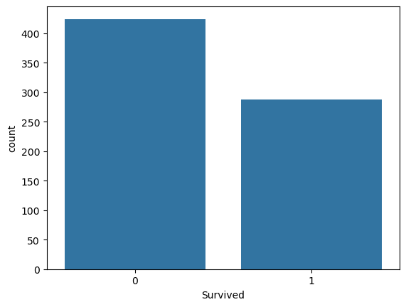

```python
sns.countplot(x='Survived', data=data)
plt.show()
```

**Implementació:**

Dividiu el *dataset* en dos subconjunts, *train* (80% de les dades) i *test* (20% de les dades). Anomeneu els conjunts com: X_train, X_test, y_train, y_test. Utilitzeu l'opció `random_state = 24`.

Podeu utilitzar la implementació `train_test_split` de `sklearn`.

```python
from sklearn.model_selection import train_test_split
X_train, X_test, y_train, y_test = train_test_split(
    X, y, test_size=0.2, random_state=24 # 0.2 = 20% per a test -> 0.8 = 80% per a train
)
```

Per poder visualitzar els resultats de cada algorisme supervisat, reduirem el dataset anterior a dues dimensions.

**NOTA**: Aquest exercici s'ha plantejat des d'un punt de vista didàctic, per la qual cosa utilitzarem en tot l'exercici el dataset reduït a dues dimensions amb l'objectiu de visualitzar les fronteres de decisió dels models. Aplicar directament reducció de la dimensionalitat no té per què ser la millor tècnica o aproximació per abordar el problema d'aprenentatge supervisat. No obstant això, ens servirà per visualitzar i aprofundir en l'enteniment sobre les fronteres que aprenen els diferents models.

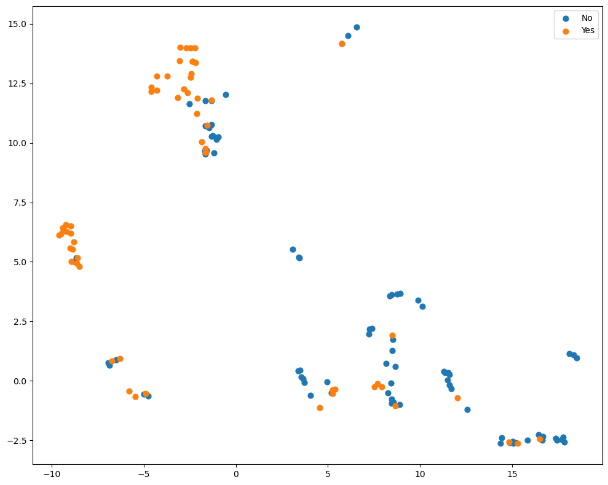

```python
scaler = StandardScaler()
X_train = scaler.fit_transform(X_train)
X_test = scaler.transform(X_test)

model = umap.UMAP(n_components=2, random_state=42, n_jobs=-1)
model.fit(X_train)
X_train_projection = model.transform(X_train)
X_test_projection = model.transform(X_test)

fig, ax = plt.subplots(1, 1, figsize=(10, 8))
for i in range(n_classes):
    ax.scatter(X_test_projection[y_test == i,0], X_test_projection[y_test == i,1], s=40, marker='o', label=labels[i])
plt.legend()
plt.tight_layout()

plt.show()
```

Al llarg de l'exercici aprendrem a veure gràficament les fronteres de decisió que ens retornen els diferents models. Per fer-ho utilitzarem la funció definida a continuació, que segueix els passos següents:

1. Crear una *meshgrid* amb els valors mínim i màxim de 'x' i 'y'.
2. Predir el classificador amb els valors de la *meshgrid*.
3. Fer un *reshape* de les dades per tenir el format corresponent.

Un cop fet això, ja podem fer el gràfic de les fronteres de decisió i afegir els punts reals. Així veurem les àrees que el model considera que són d'una classe i les que considera que són d'una altra. En posar a sobre els punts veurem si els classifica correctament a l'àrea que els correspon.

```python
# Define the function that will visualize the decision boundary
def plot_decision_boundaries(model, X_test_projection, y_test):

    # Create the meshgrid with the minimum and maximum values of the x and y axes
    x_min, x_max = X_test_projection[:, 0].min() - 1, X_test_projection[:, 0].max() + 1
    y_min, y_max = X_test_projection[:, 1].min() - 1, X_test_projection[:, 1].max() + 1

    xx, yy = np.meshgrid(np.arange(x_min, x_max, 0.05),
                         np.arange(y_min, y_max, 0.05))

    # Prediction by using all values of the meshgrid
    Z = model.predict(np.c_[xx.ravel(), yy.ravel()])

    # Define the colors (one for each class)
    cmap_light = ListedColormap(['gainsboro','lightgreen','peachpuff','lightcyan', 'pink'])
    cmap_bold = ['g','sandybrown','c','palevioletred']

    # Draw the borders
    Z = Z.reshape(xx.shape)
    plt.figure(figsize=(20,10))
    plt.pcolormesh(xx, yy, Z, cmap=cmap_light)

    # Draw the points
    for i in range(n_classes):
        plt.scatter(X_test_projection[y_test == i,0], X_test_projection[y_test == i,1],
                    s=40, marker='o', label=labels[i], c=cmap_bold[i])
    plt.legend()
    plt.xlim(xx.min(), xx.max())
    plt.ylim(yy.min(), yy.max())
    plt.show()
```

**Material extern consultat:**

[scikit-learn.(nd).*train_test_split*.scikit-learn](https://scikit-learn.org/stable/modules/generated/sklearn.model_selection.train_test_split.html)

## 1.2. KNN (1.25 punts)

En aquest punt, entendràs el funcionament de l'algorisme KNN (K-Nearest-Neighbor), que es basa en la proximitat dels punts de dades en un espai de característiques. Analitzaràs els seus avantatges i desavantatges, i comprendràs com els paràmetres que el componen influeixen en el seu comportament.

KNN és un algorisme de tipus supervisat basat en instància. Això significa:

- Supervisat: El teu conjunt de dades d'entrenament està etiquetat amb la classe o el resultat esperat.
- Basat en instància (*Lazy Learning*): L'algorisme no aprèn explícitament un model, com en la Regressió Logística o els arbres de decisió. En canvi, memoritza les instàncies d'entrenament i les utilitza com a "coneixement" en la fase de predicció.

Per entendre com funciona KNN, segueix aquests passos:

1. Calcula la distància entre l'ítem a classificar i els altres ítems del dataset d'entrenament.
2. Selecciona els "k" elements més propers, és a dir, aquells amb la distància més petita, segons el tipus de distància que utilitzis (euclidiana, cosinus, Manhattan, etc.).
3. Realitza una "votació de majoria" entre els k punts seleccionats: la classe que predomini en aquests punts decidirà la classificació final de l'ítem analitzat.

**Implementació:**

Realitza els passos següents amb el dataset d'entrenament (*train*):

1. Entrena un classificador KNN amb l'hiperparàmetre `n_neighbors=2` utilitzant el classificador `KNeighborsClassifier` de `sklearn`.
2. Calcula l'*accuracy* (precisió) del model tant en les dades de *train* com de *test*.
3. Calcula la matriu de confusió utilitzant les dades de *test*.
4. Representa gràficament la frontera de decisió amb les dades de *test*.

Si en entrenar el classificador apareix un avís (*warning*) i vols ignorar-lo, executa el codi següent abans de l'entrenament:

`import warnings`

`warnings.filterwarnings('ignore', message='^.*will change.*$', category=FutureWarning)`

Això et permetrà avaluar l'efectivitat del model KNN amb `n_neighbors=2` en el teu conjunt de dades, i entendre com es comporta en termes de classificació i separació de classes.

```python
import warnings
from sklearn.metrics import accuracy_score
warnings.filterwarnings('ignore', message='^.*will change.*$', category=FutureWarning)

# Step 1: Crear i entrenar el model KNN
knn_model = KNeighborsClassifier(n_neighbors=2)
knn_model.fit(X_train_projection, y_train)

# Step 2: Accuracy del model
predictions_data_training = knn_model.predict(X_train_projection) # Prediccions amb dades d'entrenament
predictions_data_testing = knn_model.predict(X_test_projection) # Predeiccions amb dades de testing
training_accuracy = accuracy_score(y_train, predictions_data_training)
testing_accuracy = accuracy_score(y_test, predictions_data_testing)
print(f"Accuracy dades entrenament: {training_accuracy}\n")
print(f"Accuracy dades testing: {testing_accuracy}")
```

```
Accuracy dades entrenament: 0.8611599297012302

Accuracy dades testing: 0.7412587412587412
```

S'observa una alta *accuracy* per les dades d'entrenament, però cal tenir en compte que el *dataset* amb el qual s'està treballant no és molt gran, el fet de tenir aquesta alta *accuracy* es pot deure a *overfitting*. El fet que el valor de k sigui baix en aquest *dataset* fa que el model knn sigui més sensible als valors atípics.

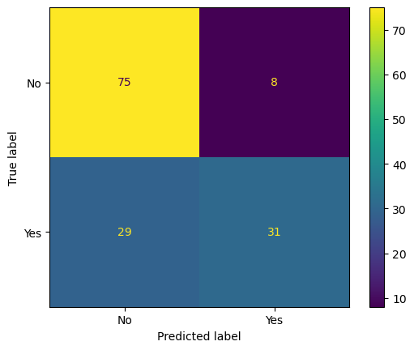

```python
from sklearn.metrics import confusion_matrix, ConfusionMatrixDisplay
import matplotlib.pyplot as plt
# Step 3: Matriu de confusio
conf_mat = confusion_matrix(y_test, predictions_data_testing)
conf_mat_display = ConfusionMatrixDisplay(confusion_matrix=conf_mat, display_labels=labels) # Per veure la matriu de confusió bonica
conf_mat_display.plot()
plt.show()
```

Segons la matriu, el model és millor predient quan la gent no va sobreviure, es demostra calculant el *True positive rate* i el *True negative_rate*:

*True positive rate* -> Quan realment és "sí", quants cops el model prediu "sí"?

*True negative_rate* -> Quan realment és "no", quants cops el model prediu "no"?

True positive rate = True positive / actual yes = 31 / (29 + 31) = 51.6%

True negative rate = True negative / actual no = 75 / (75 + 8) = 90.4%

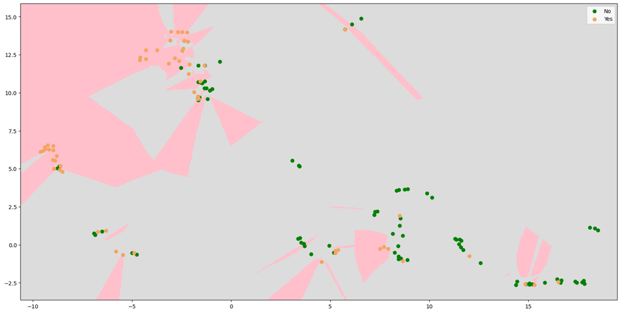

```python
# Step 4: Representar la frontera de decisió de les dades de test
plot_decision_boundaries(knn_model, X_test_projection, y_test)
```

Observant el gràfic, es pot concloure que les zones rosa són les corresponents a "Yes" i les zones de color gris són les corresponents a la classe "No".

També es confirma el que s'ha vist anteriorment a la matriu de confusió. El model és millor predient quan la gent no va sobreviure.

**Material extern consultat:**

[W3Schools.(nd).*Machine Learning - Confusion Matrix*.W3Schools](https://www.w3schools.com/python/python_ml_confusion_matrix.asp)

[scikit-learn.(nd).*KNeighborsClassifier*.scikit-learn](https://scikit-learn.org/stable/modules/generated/sklearn.neighbors.KNeighborsClassifier.html) -> Les funcions *fit()* y *predict()* queden incloses en aquest enllaç.

[scikit-learn.(nd).*accuracy_score*.scikit-learn](https://scikit-learn.org/stable/modules/generated/sklearn.metrics.accuracy_score.html)

[scikit-learn.(nd).*confusion_matrix*.scikit-learn](https://scikit-learn.org/stable/modules/generated/sklearn.metrics.confusion_matrix.html)

[data school.(25-03-2014).*Simple guide to confusion matrix terminology*. data school](https://www.dataschool.io/simple-guide-to-confusion-matrix-terminology/)

[Iker Landajuela.(2024).*Elección del número de vecinos k*.IA y Big Data](https://iabigdata-soka-4ae9e223e32444ac5ae3d78afbd55fd9aa6da1c19d9679bf.gitlab.io/post/2024-09-22-pia_knn_k_select/)

En el model que has entrenat, has fixat el paràmetre `n_neighbors` de forma arbitrària. No obstant això, és possible que amb un altre valor obtinguis una millor predicció. Per trobar el valor òptim dels paràmetres d'un model (*hyperparameter tunning*), sovint s'utilitza una cerca de reixeta (*grid search*). Això implica entrenar un model per a cada combinació possible d'hiperparàmetres i avaluar-lo mitjançant validació creuada (*cross validation*) amb 5 particions estratificades. Després, seleccionaràs la combinació d'hiperparàmetres que hagi obtingut els millors resultats.

En aquest cas, et centraràs a optimitzar un sol hiperparàmetre:

- 𝑘: el nombre de veïns que es consideren per classificar un nou exemple. Has de provar amb tots els valors entre 1 i 20.

Realitza aquest procés per identificar el nombre òptim de veïns, la qual cosa et permetrà millorar la precisió de les teves prediccions amb el model KNN.

**Implementació:**

Per calcular el valor òptim de l'hiperparàmetre *k* (`n_neighbors`), has de realitzar una cerca de reixeta amb validació creuada. Aquest procés t'ajudarà a trobar el valor òptim de *k*. Per a cada valor, calcula'n la mitjana i la desviació estàndard. Després, implementa un *lineplot* per visualitzar la precisió segons els diferents valors de l'hiperparàmetre.

Utilitza el mòdul `GridSearchCV` de `sklearn` per calcular el millor hiperparàmetre. Per a la visualització del *lineplot*, empra la llibreria `Seaborn`.

Aquests passos et permetran identificar de manera efectiva i visual el valor de *k* que maximitza la precisió del teu model KNN.

```python
knn_model = KNeighborsClassifier()
grid = GridSearchCV(estimator=knn_model, param_grid={'n_neighbors': list(range(1, 21))}, cv=5, scoring='accuracy', return_train_score=True)
grid.fit(X_train_projection, y_train) # Entrenament dels diferents models
```

```
GridSearchCV(cv=5, estimator=KNeighborsClassifier(),
             param_grid={'n_neighbors': [1, 2, 3, 4, 5, 6, 7, 8, 9, 10, 11, 12,
                                         13, 14, 15, 16, 17, 18, 19, 20]},
             return_train_score=True, scoring='accuracy')
```

```python
import pandas as pd
import seaborn as sns
# Resultats dels models entrenats
df_results = pd.DataFrame(grid.cv_results_) # splitX_test_score = accuracy de cada split de la grid search
df_results[["param_n_neighbors", "mean_train_score", "std_train_score", "mean_test_score", "std_test_score"]]
```

|  | param_n_neighbors | mean_train_score | std_train_score | mean_test_score | std_test_score |
| --- | --- | --- | --- | --- | --- |
| 0 | 1 | 1.000000 | 0.000000 | 0.732837 | 0.022932 |
| 1 | 2 | 0.861601 | 0.003604 | 0.746949 | 0.024806 |
| 2 | 3 | 0.871264 | 0.002329 | 0.783853 | 0.015974 |
| 3 | 4 | 0.853685 | 0.007270 | 0.799674 | 0.016717 |
| 4 | 5 | 0.855885 | 0.004162 | 0.785561 | 0.032817 |
| 5 | 6 | 0.845340 | 0.005726 | 0.792610 | 0.012031 |
| 6 | 7 | 0.842263 | 0.010021 | 0.792610 | 0.021273 |
| 7 | 8 | 0.834351 | 0.009801 | 0.808415 | 0.021242 |
| 8 | 9 | 0.834796 | 0.008195 | 0.806645 | 0.020341 |
| 9 | 10 | 0.835673 | 0.008455 | 0.803136 | 0.014634 |
| 10 | 11 | 0.829961 | 0.006833 | 0.803105 | 0.024467 |
| 11 | 12 | 0.829522 | 0.004438 | 0.801366 | 0.014835 |
| 12 | 13 | 0.829522 | 0.004215 | 0.801351 | 0.021055 |
| 13 | 14 | 0.828644 | 0.003808 | 0.808384 | 0.017655 |
| 14 | 15 | 0.827766 | 0.003112 | 0.810123 | 0.023297 |
| 15 | 16 | 0.829082 | 0.005017 | 0.811893 | 0.017905 |
| 16 | 17 | 0.829523 | 0.003688 | 0.813647 | 0.019426 |
| 17 | 18 | 0.827767 | 0.002346 | 0.811893 | 0.017905 |
| 18 | 19 | 0.829084 | 0.003017 | 0.813647 | 0.019426 |
| 19 | 20 | 0.820293 | 0.012227 | 0.803136 | 0.025398 |

Gràcies a la funció *cv_results__ els càlculs de les mitjanes i les desviacions es fan de manera automàtica. A més aquesta funció també proporciona dades de la _accuracy* per totes i cadascuna de les particions, tant per les dades d'entrenament com per les de *test*.

```python
# Visualitzacio en un line plot
data_to_plot = df_results[['param_n_neighbors', 'mean_test_score']] # Dades que volem graficar
data_to_plot.columns = ['k', 'accuracy'] # Renombrar columnes
data_to_plot.head()
```

|  | k | accuracy |
| --- | --- | --- |
| 0 | 1 | 0.732837 |
| 1 | 2 | 0.746949 |
| 2 | 3 | 0.783853 |
| 3 | 4 | 0.799674 |
| 4 | 5 | 0.785561 |

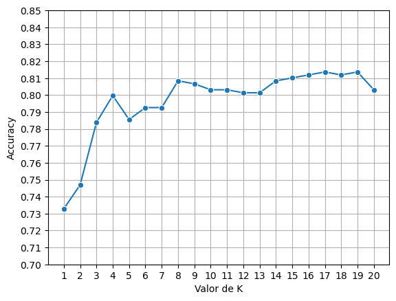

```python
import numpy as np
plt.figure()
sns.lineplot(data=data_to_plot, x='k', y='accuracy', marker='o')
plt.xlabel("Valor de K")
plt.ylabel("Accuracy")
plt.xticks(range(1, 21))
plt.yticks(np.arange(0.7, 0.85, 0.01))
plt.grid()
plt.show()
```

Observant tant el gràfic com la taula de resultats proporcionada per la funció *cv_results*, es pot observar que el valor de k que millor funciona és 17.

**Material extern consultat:**

[scikit-learn.(nd).*GridSearchCV*.scikit-learn](https://scikit-learn.org/stable/modules/generated/sklearn.model_selection.GridSearchCV.html) -> Aquest enllaç inclou, també, les funcions *fit()* i _cv_results__.

[Pandas.(nd).*pandas.DataFrame*.Pandas](https://pandas.pydata.org/docs/reference/api/pandas.DataFrame.html)

[Seaborn.(nd).*seaborn.lineplot*.Seaborn](https://seaborn.pydata.org/generated/seaborn.lineplot.html)

[Diversos autors.(diverses dates).*Plot point markers and lines in different hues but the same style with seaborn*.StackOverflow](https://stackoverflow.com/questions/52385428/plot-point-markers-and-lines-in-different-hues-but-the-same-style-with-seaborn)

[Diversos autors.(diverses dates).*How can I add grid lines to a catplot in seaborn?*.StackOverflow](https://stackoverflow.com/questions/61503183/how-can-i-add-grid-lines-to-a-catplot-in-seaborn)

[Vishal Hule.(13/04/2021).*Python range of float numbers*.PYnative Python Programming](https://pynative.com/python-range-for-float-numbers/)

**Implementació:**

Segueix aquests passos amb el dataset d'entrenament (*train*):

1. Entrena un classificador KNN utilitzant el millor hiperparàmetre que hagis trobat.
2. Calcula l'*accuracy* (precisió) del model tant en les dades de *train* com de *test*.
3. Calcula la matriu de confusió utilitzant les dades de *test*.
4. Representa gràficament la frontera de decisió amb les dades de *test*.

Aquest procés et permetrà veure com l'hiperparàmetre òptim que has identificat millora l'efectivitat del teu model KNN en la classificació de les dades.

```python
warnings.filterwarnings('ignore', message='^.*will change.*$', category=FutureWarning)

# Step 1: Crear i entrenar el model KNN
knn_optimal = KNeighborsClassifier(n_neighbors=17)
knn_optimal.fit(X_train_projection, y_train)

# Step 2: Accuracy del model
predictions_data_training = knn_optimal.predict(X_train_projection) # Prediccions amb dades d'entrenament
predictions_data_testing = knn_optimal.predict(X_test_projection) # Predeiccions amb dades de testing
training_accuracy = accuracy_score(y_train, predictions_data_training)
testing_accuracy = accuracy_score(y_test, predictions_data_testing)
print(f"Accuracy dades entrenament: {training_accuracy}\n")
print(f"Accuracy dades testing: {testing_accuracy}")
```

```
Accuracy dades entrenament: 0.827768014059754

Accuracy dades testing: 0.8041958041958042
```

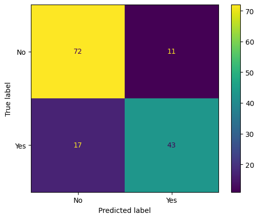

```python
# Step 3: Matriu de confusio
conf_mat = confusion_matrix(y_test, predictions_data_testing)
conf_mat_display = ConfusionMatrixDisplay(confusion_matrix=conf_mat, display_labels=labels) # Per veure la matriu de confusió bonica
conf_mat_display.plot()
plt.show()
```

*True positive rate* = 43 / (17 + 43) = 71.6%

*True negative rate* = 72 / (72 + 11) = 86.7%

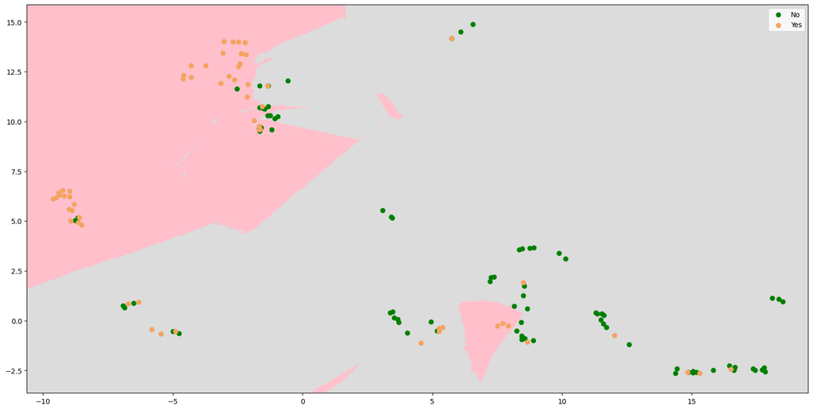

```python
# Step 4: Representar la frontera de decisió de les dades de test
plot_decision_boundaries(knn_optimal, X_test_projection, y_test)
```

**Anàlisi:**

1. Comenta els resultats obtinguts en la cerca del millor hiperparàmetre. Reflexiona sobre com va variar el rendiment del model amb els diferents valors de `n_neighbors`.
2. Analitza com es visualitza gràficament el canvi del valor de `n_neighbors`. Observes alguna tendència o patró clar? És coherent aquesta diferència entre els dos gràfics en canviar el paràmetre?
3. Examina les fronteres de decisió que has generat. La forma d'aquestes fronteres té sentit donat l'algorisme KNN utilitzat? Pensa en com l'elecció del nombre de veïns influeix en la forma de la frontera.
4. Avalua les prediccions realitzades sobre el conjunt de test. Observa'n la precisió i com es distribueixen en relació amb les fronteres de decisió. Són consistents aquestes prediccions amb el que observes a les fronteres de decisió?

Aquesta anàlisi t'ajudarà a comprendre l'eficàcia del model KNN amb diferents configuracions de `n_neighbors` i el seu impacte en la classificació de les dades.

Resposta:

Anàlisi punt 1 -> S'ha observat que en el primer model knn (k = 2) la accuracy del model per a les dades d'entrenament era d'un 86% aproximadament però per a les dades de test ha estat d'un 74%, aproximadament. És una diferència molt notòria entre ambdues puntuacions, cosa que podria indicar que el model està sobre ajustat. En canvi, amb el valor de k = 17, aquesta gran diferència entre accuracies desapareix atès que la accuracy d'entrenament és, aproximadament, d'un 82% i la de testing és d'un 80%. Aquesta petita diferència fa pensar que el model no està patint overfitting.

Anàlisi punt 3 -> En el cas del model amb un valor de k petit, s'observen unes fronteres irregulars (punxegudes) amb moltes "illes frontera". En el cas del model amb k = 17, les fronteres són més suaus i no hi ha tantes "illes frontera". Per tant, atesos els valors de k, es pot concloure que les fronteres, cadascuna per al seu model, tenen sentit.

Anàlisi punt 4 -> Per analitzar les prediccions cal mirar les matrius de confusió d'ambdós models. Quan la resposta es "sí" el model prediu "sí" un 51.6% de les vegades enfront del 71.6% del segon model. En el cas que la resposta sigui "no" el primer model prediu "no" el 90.4% de les vegades i el segon model, el 86.7% de les vegades. Per tant, es pot observar que el primer model és més bo predient quan la gent no va sobreviure i el segon model també és millor predient quan la gent va morir. El que s'observa en el cas de les prediccions "sí" s'observa que el primer model (k = 2) realitza correctament el 51.6% de les vegades mentre que el segon model (k = 17) ho fa el 71.6% de les vegades. Aquests percentatges indiquen que el segon model (k = 17) està més equilibrat. El primer model (k = 2) prediu les respostes "sí" quasi de manera aleatòria (51.6%).

## 1.3. SVM (1.25 punts)

En aquesta secció, exploraràs les Màquines de Vectors de Suport (SVM), que es basen en el concepte del *Maximal Margin Classifier* i l'hiperplà.

Un hiperplà en un espai p-dimensional es defineix com un subespai pla i afí de dimensions p-1. En dues dimensions, és una recta; en tres, un pla convencional. Per a dimensions superiors a tres, tot i que no és intuïtiu visualitzar-lo, el concepte es manté.

Quan els casos són perfectament separables de manera lineal, sorgeixen infinits possibles hiperplans. Per seleccionar el classificador òptim, utilitza el concepte de *maximal margin hyperplane*, l'hiperplà que es troba més allunyat de totes les observacions d'entrenament. Aquest es defineix calculant la distància perpendicular mínima (marge) de les observacions a un hiperplà. L'hiperplà òptim és aquell que maximitza aquest marge.

En el procés d'optimització, has de tenir en compte que només les observacions al marge o que el violen (vectors de suport) influeixen en l'hiperplà. Aquests vectors de suport són els que defineixen el classificador.

#### Els *kernels* en SVM

En situacions on no pots trobar un hiperplà que separi dues classes, és a dir, quan les classes no són linealment separables, pots utilitzar el truc del nucli (*kernel trick*). Aquest mètode et permet treballar en una dimensió nova on és possible trobar un hiperplà per separar les classes.

Igual que amb el KNN, les SVM també depenen de diversos hiperparàmetres. En aquest cas, et centraràs a optimitzar dos hiperparàmetres:

1. **C**: la regularització, que és el valor de penalització dels errors en la classificació. Aquest valor indica el compromís entre obtenir l'hiperplà amb el marge més gran possible i classificar correctament el màxim nombre d'exemples. Has de provar els valors següents: 0.01, 0.1, 1, 10, 50, 100 i 200.
2. **Gamma**: un coeficient que multiplica la distància entre dos punts en el kernel radial. En termes simples, com més petit sigui gamma, més influència tindran dos punts propers. Has de provar els valors: 0.001, 0.01, 0.1, 1 i 10.

Per validar el rendiment de l'algorisme amb cada combinació d'hiperparàmetres, utilitza la validació creuada (*cross-validation*) amb 5 particions estratificades.

**Implementació:**

1. Calcula el valor òptim dels hiperparàmetres *C* i *gamma* utilitzant una cerca de reixeta amb validació creuada. Aquest procés t'ajudarà a trobar els valors òptims.
2. Per a cada combinació de valors, calcula'n la mitjana i la desviació estàndard.
3. Fes un *heatmap* per visualitzar la precisió segons els diferents valors dels hiperparàmetres.

Utilitza el mòdul `GridSearchCV` de `sklearn` per calcular els millors hiperparàmetres amb el classificador SVC (de `SVM` de `sklearn`). Per a la visualització del *heatmap*, empra la llibreria `Seaborn`.

Aquests passos et permetran identificar de manera efectiva i visual els valors de *C* i *gamma* que maximitzen la precisió del teu model SVM.

```python
from sklearn.svm import SVC
params = {"C":[0.01, 0.1, 1, 10, 50, 100, 200], "gamma":[0.001, 0.01, 0.1, 1, 10]}
svm = SVC()
grid_svm = GridSearchCV(estimator=svm, param_grid=params, cv=5, scoring='accuracy', return_train_score=True)
grid_svm.fit(X_train_projection, y_train) # Entrenament dels diferents models
```

```
GridSearchCV(cv=5, estimator=SVC(),
             param_grid={'C': [0.01, 0.1, 1, 10, 50, 100, 200],
                         'gamma': [0.001, 0.01, 0.1, 1, 10]},
             return_train_score=True, scoring='accuracy')
```

```python
print(grid_svm.best_params_)
```

```
{'C': 1, 'gamma': 1}
```

Com es pot observar en la cèl·la anterior, els millors valors de "C" i "gamma" són 1 en ambdós casos.

```python
# Resultats dels models entrenats
df_results = pd.DataFrame(grid_svm.cv_results_) # splitX_test_score = accuracy de cada split de la grid search
df_results[["param_C", "param_gamma", "mean_train_score", "std_train_score", "mean_test_score", "std_test_score"]]
```

|  | param_C | param_gamma | mean_train_score | std_train_score | mean_test_score | std_test_score |
| --- | --- | --- | --- | --- | --- | --- |
| 0 | 0.01 | 0.001 | 0.599297 | 0.000905 | 0.599301 | 0.003615 |
| 1 | 0.01 | 0.010 | 0.599297 | 0.000905 | 0.599301 | 0.003615 |
| 2 | 0.01 | 0.100 | 0.599297 | 0.000905 | 0.599301 | 0.003615 |
| 3 | 0.01 | 1.000 | 0.599297 | 0.000905 | 0.599301 | 0.003615 |
| 4 | 0.01 | 10.000 | 0.599297 | 0.000905 | 0.599301 | 0.003615 |
| 5 | 0.10 | 0.001 | 0.724076 | 0.010773 | 0.724049 | 0.043010 |
| 6 | 0.10 | 0.010 | 0.780311 | 0.009331 | 0.780236 | 0.037363 |
| 7 | 0.10 | 0.100 | 0.779873 | 0.009859 | 0.773218 | 0.036609 |
| 8 | 0.10 | 1.000 | 0.811946 | 0.006728 | 0.804906 | 0.020444 |
| 9 | 0.10 | 10.000 | 0.652015 | 0.010288 | 0.627418 | 0.008783 |
| 10 | 1.00 | 0.001 | 0.780311 | 0.009331 | 0.780236 | 0.037363 |
| 11 | 1.00 | 0.010 | 0.780311 | 0.009331 | 0.780236 | 0.037363 |
| 12 | 1.00 | 0.100 | 0.802723 | 0.005121 | 0.783776 | 0.040944 |
| 13 | 1.00 | 1.000 | 0.835675 | 0.004953 | 0.815417 | 0.022641 |
| 14 | 1.00 | 10.000 | 0.864234 | 0.006002 | 0.789070 | 0.022523 |
| 15 | 10.00 | 0.001 | 0.780311 | 0.009331 | 0.780236 | 0.037363 |
| 16 | 10.00 | 0.010 | 0.786026 | 0.009541 | 0.769710 | 0.030100 |
| 17 | 10.00 | 0.100 | 0.834355 | 0.005040 | 0.813662 | 0.013604 |
| 18 | 10.00 | 1.000 | 0.852372 | 0.004491 | 0.799627 | 0.017255 |
| 19 | 10.00 | 10.000 | 0.887085 | 0.006852 | 0.783791 | 0.026138 |
| 20 | 50.00 | 0.001 | 0.780311 | 0.009331 | 0.780236 | 0.037363 |
| 21 | 50.00 | 0.010 | 0.787344 | 0.011360 | 0.769710 | 0.030100 |
| 22 | 50.00 | 0.100 | 0.838308 | 0.005947 | 0.810138 | 0.025648 |
| 23 | 50.00 | 1.000 | 0.855883 | 0.005934 | 0.782037 | 0.012341 |
| 24 | 50.00 | 10.000 | 0.909493 | 0.006969 | 0.760984 | 0.006506 |
| 25 | 100.00 | 0.001 | 0.781630 | 0.008049 | 0.776727 | 0.033678 |
| 26 | 100.00 | 0.010 | 0.788223 | 0.012733 | 0.769710 | 0.030100 |
| 27 | 100.00 | 0.100 | 0.840506 | 0.005411 | 0.811908 | 0.023649 |
| 28 | 100.00 | 1.000 | 0.864233 | 0.003616 | 0.775004 | 0.013835 |
| 29 | 100.00 | 10.000 | 0.925308 | 0.005187 | 0.759230 | 0.020405 |
| 30 | 200.00 | 0.001 | 0.782070 | 0.007776 | 0.776727 | 0.033678 |
| 31 | 200.00 | 0.010 | 0.791740 | 0.009866 | 0.773218 | 0.034887 |
| 32 | 200.00 | 0.100 | 0.841827 | 0.005044 | 0.810169 | 0.025364 |
| 33 | 200.00 | 1.000 | 0.868187 | 0.004479 | 0.776758 | 0.012734 |
| 34 | 200.00 | 10.000 | 0.935411 | 0.003331 | 0.743425 | 0.021578 |

Observant la taula de resultats, es confirma la hipòtesi de que els millors valors són C = 1 i gamma = 1

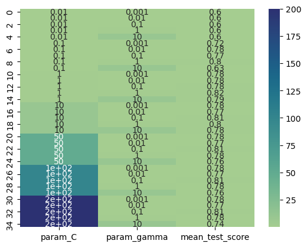

```python
results_svm_to_plot = df_results[["param_C", "param_gamma", "mean_test_score"]]
matrix_data_to_plot = results_svm_to_plot.pivot(index="param_C", columns="param_gamma", values="mean_test_score")
plt.figure()
sns.heatmap(results_svm_to_plot, annot=True, cmap='crest')
plt.show()
```

**Material extern consultat:**

[scikit-learn.(nd).*SVC*.scikit-learn](https://scikit-learn.org/stable/modules/generated/sklearn.svm.SVC.html)

[scikit-learn.(nd).*GridSearchCV*.scikit-learn](https://scikit-learn.org/stable/modules/generated/sklearn.model_selection.GridSearchCV.html) -> En aquesta ocasió s'ha consultat la funció _best_params__

[seaborn.(nd).*seaborn.heatmap*.seaborn](https://seaborn.pydata.org/generated/seaborn.heatmap.html)

**Implementació:**

Realitza els passos següents amb el dataset d'entrenament (*train*):

1. Entrena un model SVM utilitzant la millor combinació de paràmetres que hagis trobat.
2. Calcula l'*accuracy* (precisió) del model tant en les dades de *train* com de *test*.
3. Calcula la matriu de confusió utilitzant les dades de *test*.
4. Representa gràficament la frontera de decisió amb les dades de *test*.

Aquest procés et permetrà veure com la millor combinació de paràmetres millora l'efectivitat del teu model SVM en la classificació de les dades.

```python
# Step 1: Optimal model
svm_optimal = SVC(C=1, gamma=1)
svm_optimal.fit(X_train_projection, y_train) # Entrenament dels diferents models

# Step 2: Metrics
predictions_data_training = svm_optimal.predict(X_train_projection) # Prediccions amb dades d'entrenament
predictions_data_testing = svm_optimal.predict(X_test_projection) # Predeiccions amb dades de testing
training_accuracy = accuracy_score(y_train, predictions_data_training)
testing_accuracy = accuracy_score(y_test, predictions_data_testing)
print(f"Accuracy dades entrenament: {training_accuracy}\n")
print(f"Accuracy dades testing: {testing_accuracy}")
```

```
Accuracy dades entrenament: 0.8330404217926186

Accuracy dades testing: 0.7902097902097902
```

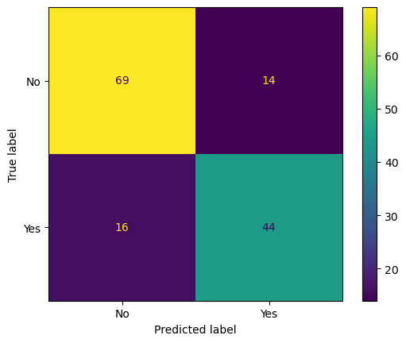

```python
# Step 3: Confusion matrix:
conf_mat = confusion_matrix(y_test, predictions_data_testing)
conf_mat_display = ConfusionMatrixDisplay(confusion_matrix=conf_mat, display_labels=labels) # Per veure la matriu de confusió bonica
conf_mat_display.plot()
plt.show()
```

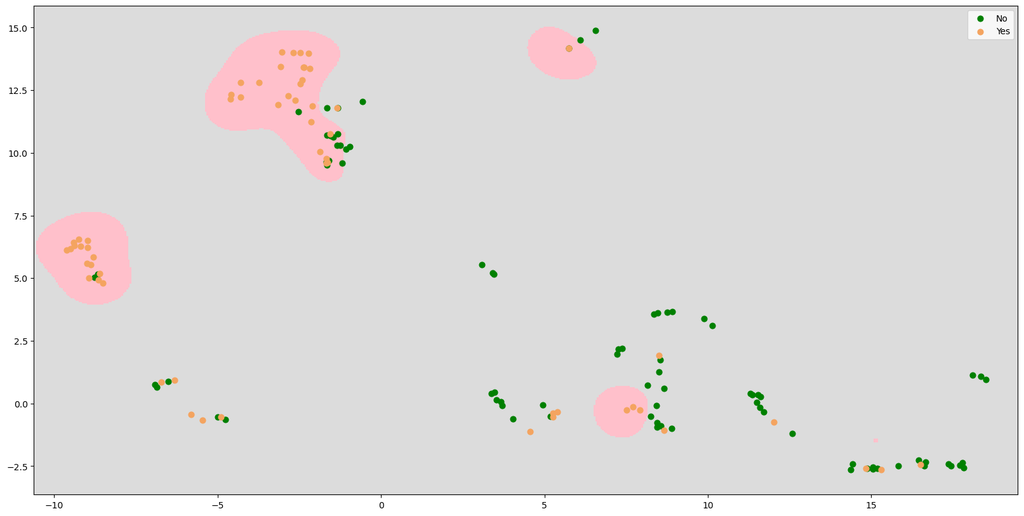

```python
# Step 4: Boundaries
plot_decision_boundaries(svm_optimal, X_test_projection, y_test)
```

**Anàlisi:**

1. Comenta els resultats obtinguts en la cerca dels millors hiperparàmetres. Reflexiona sobre com va variar el rendiment del model SVM amb els diferents valors de *C* i *gamma*. Considera si els valors òptims trobats tenen sentit en el context del teu conjunt de dades.
2. Examina les fronteres de decisió que has generat amb el model SVM. La forma d'aquestes fronteres és coherent amb el que esperaries de l'algorisme utilitzat? Pensa en com la combinació d'hiperparàmetres seleccionats podria influir en la forma de les fronteres.
3. Avalua les prediccions realitzades sobre el conjunt de test. Observa'n la precisió i com es distribueixen en relació amb les fronteres de decisió. Són consistents aquestes prediccions amb el que observes a les fronteres de decisió?

Aquesta anàlisi t'ajudarà a comprendre l'eficàcia del model SVM amb els hiperparàmetres seleccionats i el seu impacte en la classificació de les dades.

Resposta:

Anàlisi punt 2 -> En el mapa s'observa que la classe predominant és el "no" ja que ocupa la major part del mapa. Per la classe del "sí" s'observen "petites illes" on es concentren els punts de color taronja. Les "illes" més petites són aquelles on el model té més probabilitats d'equivocar-se a l'hora de fer la predicció, ja que són regions estretes. Atèsos els valors de C i gamma la forma de les fronteres és coherent.

Anàlisi punt 3 -> Si s'observen tant el gràfic de les fronteres de decisió com la matriu de confusió es pot veure que les distribucions són consistents amb el que s'observa a la matriu. Tot i que en el gràfic de fronteres hi ha algun punt que està al límit entre les dues classes i això pot portar a confusió a l'hora de determinar si el model les considera d'una o altra classe.

```python
print(df_results['mean_train_score'].mean())
print(df_results['std_train_score'].mean())
print(df_results['mean_test_score'].mean())
print(df_results['std_train_score'].mean())
```

```
0.7868167121099453
0.006472132009658795
0.7508022268059529
0.006472132009658795
```

**Material extern consultat:**

[A Man Kumar.(17/12/2018).*C and Gamma in SVM*.Medium](https://medium.com/@myselfaman12345/c-and-gamma-in-svm-e6cee48626be)

## 1.4. Arbres de decisió (1.25 punts)

En aquesta secció, exploraràs els arbres de decisió, models predictius que es basen en regles binàries (sí/no) per classificar les observacions segons els seus atributs i predir el valor de la variable resposta. Aquests arbres poden ser classificadors, com en el teu exemple, o regressors per predir variables contínues.

#### Construcció d'un Arbre

Per construir un arbre, segueix l'algorisme de *recursive binary splitting*:

1. Comença a la part superior de l'arbre, on totes les observacions pertanyen a la mateixa regió.
2. Identifica tots els possibles punts de tall per a cadascun dels predictors. Aquests punts de tall són els diferents nivells dels predictors.
3. Avalua les possibles divisions per a cada predictor utilitzant una mesura específica. En els classificadors, aquestes mesures poden ser el *classification error rate*, l'índex Gini, l'entropia o el chi-quadrat.

Comprendre aquests passos t'ajudarà a entendre com els arbres de decisió creen divisions binàries per classificar les dades i com aquests es poden aplicar tant per a classificació com per a regressió.

**Implementació:**

Segueix aquests passos:

1. Amb el dataset d'entrenament, entrena un arbre de decisió utilitzant el classificador `DecisionTreeClassifier` de la biblioteca `tree` de `sklearn`.
2. Calcula l'*accuracy* (precisió) del model tant en les dades de *train* com de *test*.
3. Calcula la matriu de confusió utilitzant les dades de *test*.
4. Representa gràficament la frontera de decisió amb les dades de *test*.
5. Representa l'arbre de decisió. Pots utilitzar el comandament `plot.tree` de la biblioteca `tree` de `sklearn`.

Aquests passos et permetran avaluar com l'arbre de decisió es comporta en el teu conjunt de dades, tant en termes de classificació com en la seva representació visual.

```python
from sklearn.tree import DecisionTreeClassifier
# Step 1: Entrenar un arbre
tree_model = DecisionTreeClassifier()
tree_model.fit(X_train_projection, y_train)

# Step 2: Accuracy
predictions_data_training = tree_model.predict(X_train_projection) # Prediccions amb dades d'entrenament
predictions_data_testing = tree_model.predict(X_test_projection) # Predeiccions amb dades de testing
training_accuracy = accuracy_score(y_train, predictions_data_training)
testing_accuracy = accuracy_score(y_test, predictions_data_testing)
print(f"Accuracy dades entrenament: {training_accuracy}\n")
print(f"Accuracy dades testing: {testing_accuracy}")
```

```
Accuracy dades entrenament: 1.0

Accuracy dades testing: 0.7202797202797203
```

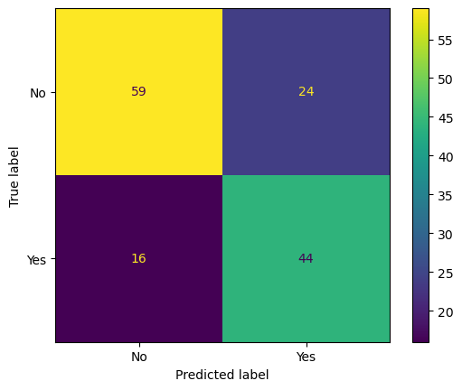

```python
# Step 3: Matriu de confusió
conf_mat = confusion_matrix(y_test, predictions_data_testing)
conf_mat_display = ConfusionMatrixDisplay(confusion_matrix=conf_mat, display_labels=labels) # Per veure la matriu de confusió bonica
conf_mat_display.plot()
plt.show()
```

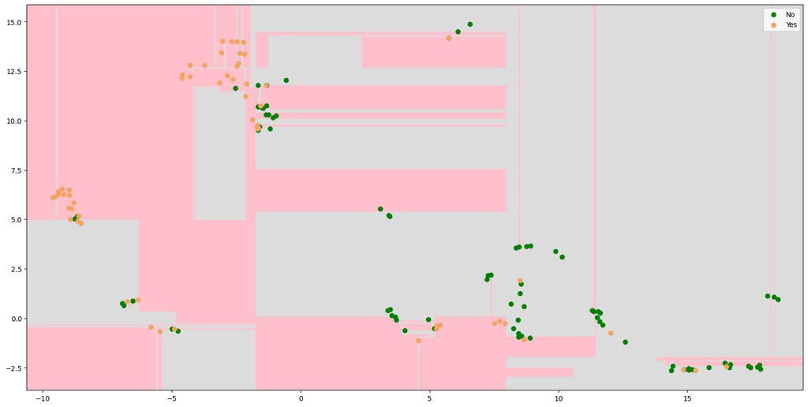

```python
# Step 4: Frontera
plot_decision_boundaries(tree_model, X_test_projection, y_test)
```

```python
from sklearn import tree
# Step 5: Representar arbre
plt.figure(figsize=(200,100))
tree.plot_tree(tree_model, filled=True, class_names=True)
plt.show()
```

[figure not shown]

**Anàlisi:**

1. Avalua i comenta els resultats obtinguts amb l'arbre de decisió. Considera tant l'*accuracy* del model en els conjunts de *train* i *test* com els resultats de la matriu de confusió.
2. Reflexiona sobre com la frontera de decisió visualitzada en el conjunt de *test* s'alinea amb els resultats obtinguts. És coherent amb el que esperaries d'un arbre de decisió?
3. Observa la representació gràfica de l'arbre. Analitza com les diferents ramificacions i decisions preses a l'arbre expliquen el comportament del model i el seu impacte en la classificació de les dades.

Aquesta anàlisi t'ajudarà a comprendre en profunditat el funcionament i l'eficàcia de l'arbre de decisió en el teu conjunt de dades específic.

Resposta:

Anàlisi punt 1 -> L'accuracy obtinguda per a les dades d'entrenament és d'1. Això indica que l'arbre sempre classifica correctament les dades que ha vist durant l'entrenament. En el cas de les dades de testing l'accuracy és del 72%, la qual cosa indica que l'arbre no és capaç de funcionar del tot bé amb dades que no ha vist durant l'etapa d'entrenament.

La matriu de confusió mostra que quan la resposta és "sí" l'arbre classifica com a sí el 73% de les vegades (true positive rate) i quan la resposta és "no", l'arbre classifica com a "no" el 72% de les respostes (true negative rate). Per tant, observant aquests percentatges es pot concloure que l'arbre està bastant equilibrat i que no hi ha una resposta que destaqui per sobre de l'altra.

Anàlisi punt 2 -> Observant el gràfic de les fronteres es pot observar que l'arbre està sobreentrenat, ja que es poden veure diverses "illes" a més, les fronteres són irregulars. Si l'arbre no estigués patint overffiting, no hi hauria tantes illes i les fronteres no serien tan irregulars.

Anàlisi punt 3 -> L'arbre és tan gran que impossibilita veure'l apropiadament per realitzar-ne una anàlisi. Inclús fent zoom in al màxim, no es pot veure bé.

#### Evitant l'*overfitting*

El procés de construcció d'arbres descrit tendeix a reduir ràpidament l'error d'entrenament, per la qual cosa generalment el model s'ajusta molt bé a les observacions utilitzades com a entrenament (conjunt de *train*). Com a conseqüència, els arbres de decisió tendeixen a l'*overfitting*.

Per evitar l'*overfitting* en els arbres de decisió, és crucial que modifiquis certs hiperparàmetres del model de la manera següent:

1. Utilitza l'hiperparàmetre `max_depth`, que defineix la profunditat màxima de l'arbre. Hauràs d'explorar els valors entre 4 i 10 per trobar l'equilibri adequat entre la complexitat del model i la seva capacitat per generalitzar.
2. Estableix l'hiperparàmetre `min_samples_split`, que és el nombre mínim d'observacions que ha de tenir una fulla de l'arbre abans de considerar una divisió. Experimenta amb valors com 2, 10, 20, 50 i 100 per assegurar-te que l'arbre no es torni massa específic per a les observacions d'entrenament.

Ajustant aquests hiperparàmetres, podràs controlar la tendència de l'arbre de decisió a sobreajustar-se al conjunt d'entrenament, millorant així la seva capacitat per realitzar prediccions efectives en noves dades.

**Implementació:**

1. Calcula el valor òptim dels hiperparàmetres `max_depth` i `min_samples_split` utilitzant una cerca de reixeta amb validació creuada. Aquest procés t'ajudarà a trobar els valors òptims que evitaran el sobreajustament.
2. Per a cada combinació de valors, calcula'n la mitjana i la desviació estàndard.
3. Fes un *heatmap* per visualitzar la precisió segons els diferents valors dels hiperparàmetres.

Utilitza el mòdul `GridSearchCV` de `sklearn` per calcular els millors hiperparàmetres amb el classificador `DecisionTreeClassifier` de `tree` de `sklearn`. Per a la visualització del *heatmap*, empra la llibreria `Seaborn`.

Aquests passos et permetran identificar de manera efectiva i visual els valors de `max_depth` i `min_samples_split` que maximitzen la precisió del teu arbre de decisió, minimitzant el risc de sobreajustament.

```python
params = {"max_depth":list(range(4, 11)), "min_samples_split":[2, 10, 20, 50, 100]}
tree_model = DecisionTreeClassifier()
grid_tree = GridSearchCV(estimator=tree_model, param_grid=params, cv=5, scoring='accuracy', return_train_score=True)
grid_tree.fit(X_train_projection, y_train) # Entrenament dels diferents models
```

```
GridSearchCV(cv=5, estimator=DecisionTreeClassifier(),
             param_grid={'max_depth': [4, 5, 6, 7, 8, 9, 10],
                         'min_samples_split': [2, 10, 20, 50, 100]},
             return_train_score=True, scoring='accuracy')
```

```python
# Resultats dels models entrenats
df_results = pd.DataFrame(grid_tree.cv_results_) # splitX_test_score = accuracy de cada split de la grid search
df_results[["param_max_depth", "param_min_samples_split", "mean_train_score", "std_train_score", "mean_test_score", "std_test_score"]]
```

|  | param_max_depth | param_min_samples_split | mean_train_score | std_train_score | mean_test_score | std_test_score |
| --- | --- | --- | --- | --- | --- | --- |
| 0 | 4 | 2 | 0.851052 | 0.005165 | 0.783853 | 0.023069 |
| 1 | 4 | 10 | 0.849733 | 0.006384 | 0.783853 | 0.023069 |
| 2 | 4 | 20 | 0.844022 | 0.005099 | 0.776820 | 0.026211 |
| 3 | 4 | 50 | 0.826890 | 0.006400 | 0.776836 | 0.036009 |
| 4 | 4 | 100 | 0.820737 | 0.003324 | 0.794380 | 0.021151 |
| 5 | 5 | 2 | 0.882246 | 0.008455 | 0.764509 | 0.029481 |
| 6 | 5 | 10 | 0.873015 | 0.009952 | 0.761000 | 0.026107 |
| 7 | 5 | 20 | 0.860276 | 0.009042 | 0.757476 | 0.025712 |
| 8 | 5 | 50 | 0.834799 | 0.006386 | 0.773327 | 0.033676 |
| 9 | 5 | 100 | 0.820737 | 0.003324 | 0.794380 | 0.021151 |
| 10 | 6 | 2 | 0.901576 | 0.006795 | 0.764509 | 0.023033 |
| 11 | 6 | 10 | 0.887076 | 0.007516 | 0.755737 | 0.019224 |
| 12 | 6 | 20 | 0.871700 | 0.007240 | 0.746949 | 0.024178 |
| 13 | 6 | 50 | 0.832602 | 0.006988 | 0.773327 | 0.037153 |
| 14 | 6 | 100 | 0.820737 | 0.003324 | 0.794380 | 0.021151 |
| 15 | 7 | 2 | 0.931894 | 0.005057 | 0.743394 | 0.042484 |
| 16 | 7 | 10 | 0.898063 | 0.004152 | 0.743440 | 0.024747 |
| 17 | 7 | 20 | 0.878732 | 0.007041 | 0.738177 | 0.029749 |
| 18 | 7 | 50 | 0.832602 | 0.006988 | 0.771573 | 0.036551 |
| 19 | 7 | 100 | 0.820737 | 0.003324 | 0.794380 | 0.021151 |
| 20 | 8 | 2 | 0.952107 | 0.002189 | 0.743440 | 0.030335 |
| 21 | 8 | 10 | 0.904654 | 0.004374 | 0.736392 | 0.022719 |
| 22 | 8 | 20 | 0.882247 | 0.007726 | 0.738162 | 0.027167 |
| 23 | 8 | 50 | 0.836558 | 0.006691 | 0.769818 | 0.034542 |
| 24 | 8 | 100 | 0.820737 | 0.003324 | 0.794380 | 0.021151 |
| 25 | 9 | 2 | 0.963971 | 0.001766 | 0.727573 | 0.025006 |
| 26 | 9 | 10 | 0.906852 | 0.003628 | 0.731129 | 0.029469 |
| 27 | 9 | 20 | 0.883566 | 0.006982 | 0.732899 | 0.029372 |
| 28 | 9 | 50 | 0.833920 | 0.006720 | 0.773327 | 0.037153 |
| 29 | 9 | 100 | 0.820737 | 0.003324 | 0.794380 | 0.021151 |
| 30 | 10 | 2 | 0.975391 | 0.005973 | 0.734637 | 0.029937 |
| 31 | 10 | 10 | 0.909488 | 0.002978 | 0.732883 | 0.027887 |
| 32 | 10 | 20 | 0.883566 | 0.006982 | 0.734653 | 0.028223 |
| 33 | 10 | 50 | 0.833920 | 0.006720 | 0.771573 | 0.036551 |
| 34 | 10 | 100 | 0.820737 | 0.003324 | 0.794380 | 0.021151 |

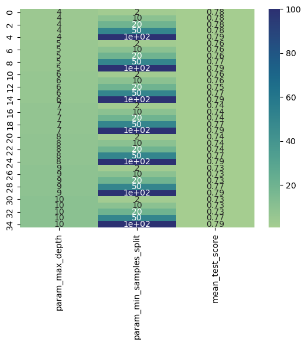

```python
results_tree_to_plot = df_results[["param_max_depth", "param_min_samples_split", "mean_test_score"]]
matrix_data_to_plot = results_tree_to_plot.pivot(index="param_max_depth", columns="param_min_samples_split", values="mean_test_score")
plt.figure()
sns.heatmap(results_tree_to_plot, annot=True, cmap='crest')
plt.show()
```

```python
print(grid_tree.best_params_)
```

```
{'max_depth': 4, 'min_samples_split': 100}
```

Observant la taula de resultats es conclou que la millor combinació de paràmetres és max_depth = 4 i min_samples_split = 100, hipòtesi que es confirma gràcies al resultat de la funció _best_params__

**Implementació:**

1. Entrena un arbre de decisió amb el dataset d'entrenament (*train*) utilitzant la millor combinació de paràmetres que hagis trobat.
2. Calcula l'*accuracy* (precisió) del model tant en les dades de *train* com de *test*.
3. Calcula la matriu de confusió utilitzant les dades de *test*.
4. Representa gràficament la frontera de decisió amb les dades de *test*.
5. Representa l'arbre de decisió.

Aquests passos et permetran avaluar com l'arbre de decisió, ajustat amb els hiperparàmetres òptims, es comporta en el teu conjunt de dades, tant en termes de classificació com en la seva representació visual.

```python
# Step 1: Model optim
tree_model_optimal = DecisionTreeClassifier(max_depth=4, min_samples_split=100)
tree_model_optimal.fit(X_train_projection, y_train)

# Step 2: Accuracy
predictions_data_training = tree_model_optimal.predict(X_train_projection) # Prediccions amb dades d'entrenament
predictions_data_testing = tree_model_optimal.predict(X_test_projection) # Predeiccions amb dades de testing
training_accuracy = accuracy_score(y_train, predictions_data_training)
testing_accuracy = accuracy_score(y_test, predictions_data_testing)
print(f"Accuracy dades entrenament: {training_accuracy}\n")
print(f"Accuracy dades testing: {testing_accuracy}")
```

```
Accuracy dades entrenament: 0.8189806678383128

Accuracy dades testing: 0.8111888111888111
```

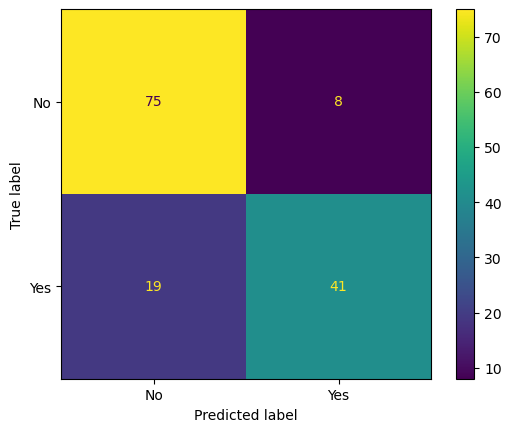

```python
# Step 3: Matriu de confusió
conf_mat = confusion_matrix(y_test, predictions_data_testing)
conf_mat_display = ConfusionMatrixDisplay(confusion_matrix=conf_mat, display_labels=labels) # Per veure la matriu de confusió bonica
conf_mat_display.plot()
plt.show()
```

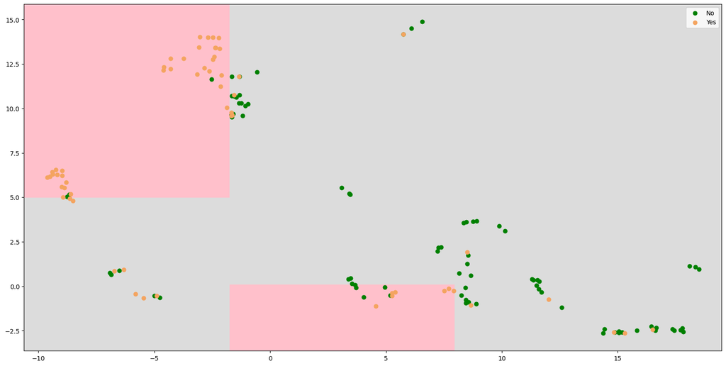

```python
# Step 4: Frontera
plot_decision_boundaries(tree_model_optimal, X_test_projection, y_test)
```

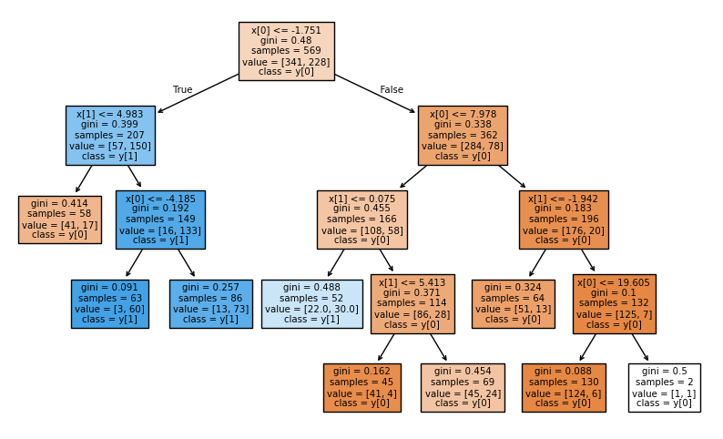

```python
# Step 5: Representar arbre
plt.figure(figsize=(10,6))
tree.plot_tree(tree_model_optimal, filled=True, class_names=True)
plt.show()
```

**Anàlisi:**

1. Avalua i comenta els resultats obtinguts en la cerca dels millors hiperparàmetres. Considera com la combinació òptima de `max_depth` i `min_samples_split` ha impactat el rendiment de l'arbre de decisió.
2. Examina les fronteres de decisió generades amb el conjunt de *test*. Reflexiona sobre si la forma d'aquestes fronteres és coherent amb el que esperaries d'un arbre de decisió configurat amb aquests hiperparàmetres.
3. Analitza les prediccions realitzades sobre el conjunt de test. Observa'n la precisió i com es distribueixen en relació amb les fronteres de decisió. Són consistents aquestes prediccions amb l'estructura de l'arbre de decisió i les fronteres observades?

Aquesta anàlisi t'ajudarà a comprendre l'eficàcia de l'arbre de decisió amb els hiperparàmetres seleccionats i el seu impacte en la classificació de les dades.

Resposta:

Anàlisi punt 1 -> En aquesta ocasió, amb els paràmetres òptims, tant l'accuracy d'entrenament com la de test és del 81%. Això és un indicador de què el overffiting ha estat mitigat.

Anàlisi punt 2 -> En el gràfic de fronteres es pot confirmar novament que el overffitgin ha estat mitigat, ja que es poden observar només dues illes i unes fronteres no irregulars.

Anàlisi punt 3 -> En aquesta ocasió sí que és el que s'espera veure, perquè no tenim més que dues "illes" (l'ideal sería només 1 "illa" per cada color) i les fronteres no són irregulars, és a dir, no hi ha "mini illes" que fan que les fronteres siguin molt sensibles a l'hora de classificar.

**Material extern consultat:**

[scikit-learn.(nd).*DecisionTreeClassifier*.scikit-learn](https://scikit-learn.org/stable/modules/generated/sklearn.tree.DecisionTreeClassifier.html)

[scikit-learn.(nd).*plot_tree*.scikit-learn](https://scikit-learn.org/stable/modules/generated/sklearn.tree.plot_tree.html)

# 2. Comprensió d'algorismes supervisats (3.25 punts)

En aquest exercici aprofundirem en la comprensió dels algorismes supervisats que hem estudiat, en concret, Arbres de decisió i Knn. Per fer-ho treballarem amb un problema de regressió molt senzill (un únic atribut descriptiu) que es resoldria de forma directa amb una regressió lineal.

**IMPORTANT:** En aquest exercici no es poden utilitzar altres models, ni tècniques com a *ensemble learning* ni fer servir altres llibreries diferents de les indicades i importades a l'inici de la PAC. En aquest exercici hem de seguir les indicacions que es proporcionaran a cada secció, on ens centrarem a transformar el problema (dades) per aconseguir resoldre el nostre problema.

En aquest exercici ens donarem suport en la funció *plot_regression*, la qual ens permetrà representar de forma senzilla les solucions obtingudes.

**NOTA:** En aquest exercici realitzarem moltes anàlisis visuals amb l'objectiu d'aprofundir en els coneixements teòrics vistos al mòdul. Aquest exercici es realitzarà amb una finalitat didàctica; en la realitat sempre cal donar suport en diverses mètriques objectives per al problema que estiguem resolent, a més, per descomptat, de visualitzar si és possible el problema que estiguem resolent.

```python
def plot_regression(x_train, y_train, x_test, y_test, preds_train=None, preds_test=None):
    plt.figure(figsize=(15, 8))
    plt.scatter(x_train, y_train, s=60, marker='8', label='train')
    plt.scatter(x_test, y_test, s=60, marker='8', label='test')

    if preds_train is not None:
        plt.scatter(x_train, preds_train, s=60, marker='8', label='preds_train')

    if preds_test is not None:
        plt.scatter(x_test, preds_test, s=60, marker='8', label='preds_test')

    plt.legend()
    plt.show()
```

A la cel·la següent es defineix el conjunt de dades i se separa en entrenament i test, com es pot observar a la gràfica.

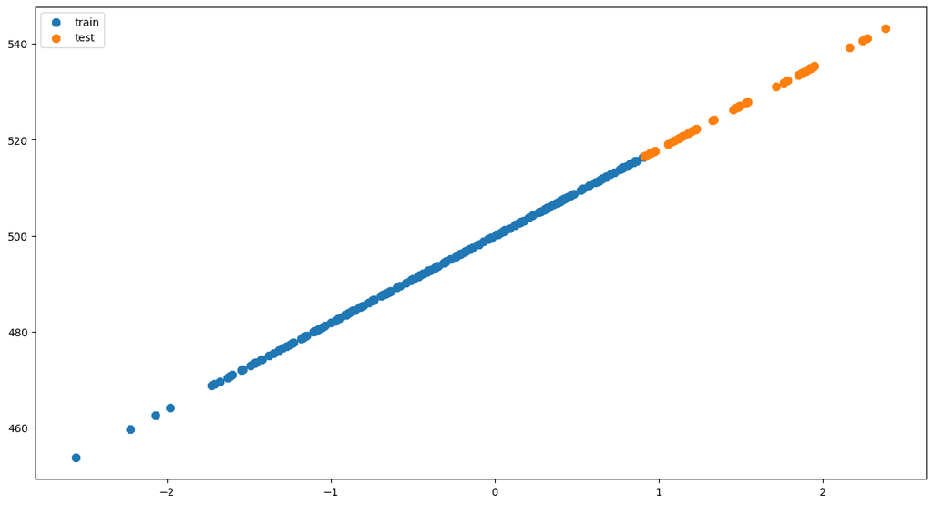

```python
n_samples = 250
test_size = int(n_samples * 0.2)
X, y = datasets.make_regression(n_features=1, n_samples=n_samples, bias=500, noise=0, random_state=0)
X, y = zip(*sorted(zip(X,y)))
X = np.array(X); y = np.array(y)

X_train = X[:-test_size]
X_test = X[-test_size:]

y_train = y[:-test_size]
y_test = y[-test_size:]

plot_regression(X_train, y_train, X_test, y_test)
```

**Implementació:**

1. Calcula el valor òptim dels hiperparàmetres `max_depth` i `min_samples_split` per a un arbre de decisió utilitzant una cerca de reixeta amb validació creuada i la mètrica 'r2_score'. Aquest procés t'ajudarà a trobar els valors òptims que evitaran el sobreajustament.
2. Per a cada combinació de valors, calcula'n la mitjana i la desviació estàndard.
3. Mostra el valor òptim trobat per als dos hiperparàmetres.
4. Entrena un arbre de decisió amb el dataset d'entrenament (*train*) utilitzant la millor combinació de paràmetres que hagis trobat.
5. Realitza la predicció sobre el conjunt d'entrenament (*train*) i test per representar gràficament els resultats utilitzant la funció `plot_regression`. Tingues en compte que necessitem visualitzar les 4 sèries: *train*, *test*, predicció sobre *train* i predicció sobre *test*.

Utilitza el mòdul `GridSearchCV` de `sklearn` per calcular els millors hiperparàmetres amb el classificador `DecisionTreeRegressor` de `tree` de `sklearn`.

```python
from sklearn.tree import DecisionTreeRegressor
from sklearn.metrics import r2_score
# Step 1: Cerca dels millors hiperparàmetres
params = {"max_depth":list(range(1, 11)), "min_samples_split":[2, 10, 20, 50, 100]}
tree_regressor = DecisionTreeRegressor()
grid_tree = GridSearchCV(estimator=tree_regressor, param_grid=params, cv=5, scoring='r2', return_train_score=True)
grid_tree.fit(X_train, y_train) # Entrenament dels diferents models
```

```
GridSearchCV(cv=5, estimator=DecisionTreeRegressor(),
             param_grid={'max_depth': [1, 2, 3, 4, 5, 6, 7, 8, 9, 10],
                         'min_samples_split': [2, 10, 20, 50, 100]},
             return_train_score=True, scoring='r2')
```

```python
# Step 2: Resultats dels models entrenats -> Mitjanes i desviacions
df_results = pd.DataFrame(grid_tree.cv_results_) # splitX_test_score = accuracy de cada split de la grid search
df_results[["param_max_depth", "param_min_samples_split", "mean_train_score", "std_train_score", "mean_test_score", "std_test_score"]]
```

|  | param_max_depth | param_min_samples_split | mean_train_score | std_train_score | mean_test_score | std_test_score |
| --- | --- | --- | --- | --- | --- | --- |
| 0 | 1 | 2 | 0.734914 | 5.235929e-02 | -15.819260 | 9.349851 |
| 1 | 1 | 10 | 0.734914 | 5.235929e-02 | -15.819260 | 9.349851 |
| 2 | 1 | 20 | 0.734914 | 5.235929e-02 | -15.819260 | 9.349851 |
| 3 | 1 | 50 | 0.734914 | 5.235929e-02 | -15.819260 | 9.349851 |
| 4 | 1 | 100 | 0.734914 | 5.235929e-02 | -15.819260 | 9.349851 |
| 5 | 2 | 2 | 0.925979 | 1.215175e-02 | -6.806060 | 2.917508 |
| 6 | 2 | 10 | 0.925979 | 1.215175e-02 | -6.806060 | 2.917508 |
| 7 | 2 | 20 | 0.925979 | 1.215175e-02 | -6.806060 | 2.917508 |
| 8 | 2 | 50 | 0.920442 | 1.302970e-02 | -7.470617 | 3.493736 |
| 9 | 2 | 100 | 0.797204 | 7.457166e-02 | -13.410714 | 8.546199 |
| 10 | 3 | 2 | 0.981815 | 5.094976e-03 | -2.777583 | 1.133467 |
| 11 | 3 | 10 | 0.981815 | 5.094976e-03 | -2.777583 | 1.133467 |
| 12 | 3 | 20 | 0.979756 | 4.899037e-03 | -2.908565 | 0.891360 |
| 13 | 3 | 50 | 0.942594 | 1.980556e-02 | -5.291240 | 2.155708 |
| 14 | 3 | 100 | 0.797204 | 7.457166e-02 | -13.410714 | 8.546199 |
| 15 | 4 | 2 | 0.995697 | 1.046791e-03 | -1.492227 | 0.818542 |
| 16 | 4 | 10 | 0.994545 | 1.414719e-03 | -1.553016 | 0.728232 |
| 17 | 4 | 20 | 0.989202 | 4.667689e-03 | -2.133693 | 0.944009 |
| 18 | 4 | 50 | 0.942594 | 1.980556e-02 | -5.291240 | 2.155708 |
| 19 | 4 | 100 | 0.797204 | 7.457166e-02 | -13.410714 | 8.546199 |
| 20 | 5 | 2 | 0.999078 | 2.020269e-04 | -1.060474 | 0.899816 |
| 21 | 5 | 10 | 0.997050 | 8.140412e-04 | -1.359004 | 0.809013 |
| 22 | 5 | 20 | 0.989467 | 4.654454e-03 | -2.027734 | 0.945133 |
| 23 | 5 | 50 | 0.942594 | 1.980556e-02 | -5.291240 | 2.155708 |
| 24 | 5 | 100 | 0.797204 | 7.457166e-02 | -13.410714 | 8.546199 |
| 25 | 6 | 2 | 0.999860 | 1.920339e-05 | -0.849738 | 0.929240 |
| 26 | 6 | 10 | 0.997183 | 8.439304e-04 | -1.306969 | 0.822399 |
| 27 | 6 | 20 | 0.989467 | 4.654454e-03 | -2.027734 | 0.945133 |
| 28 | 6 | 50 | 0.942594 | 1.980556e-02 | -5.291240 | 2.155708 |
| 29 | 6 | 100 | 0.797204 | 7.457166e-02 | -13.410714 | 8.546199 |
| 30 | 7 | 2 | 0.999982 | 1.901751e-06 | -0.773735 | 0.913520 |
| 31 | 7 | 10 | 0.997186 | 8.443673e-04 | -1.306969 | 0.822399 |
| 32 | 7 | 20 | 0.989467 | 4.654454e-03 | -2.027734 | 0.945133 |
| 33 | 7 | 50 | 0.942594 | 1.980556e-02 | -5.291240 | 2.155708 |
| 34 | 7 | 100 | 0.797204 | 7.457166e-02 | -13.410714 | 8.546199 |
| 35 | 8 | 2 | 0.999999 | 2.130729e-07 | -0.768150 | 0.915514 |
| 36 | 8 | 10 | 0.997186 | 8.443673e-04 | -1.306969 | 0.822399 |
| 37 | 8 | 20 | 0.989467 | 4.654454e-03 | -2.027734 | 0.945133 |
| 38 | 8 | 50 | 0.942594 | 1.980556e-02 | -5.291240 | 2.155708 |
| 39 | 8 | 100 | 0.797204 | 7.457166e-02 | -13.410714 | 8.546199 |
| 40 | 9 | 2 | 1.000000 | 2.248817e-08 | -0.766195 | 0.915933 |
| 41 | 9 | 10 | 0.997186 | 8.443673e-04 | -1.306969 | 0.822399 |
| 42 | 9 | 20 | 0.989467 | 4.654454e-03 | -2.027734 | 0.945133 |
| 43 | 9 | 50 | 0.942594 | 1.980556e-02 | -5.291240 | 2.155708 |
| 44 | 9 | 100 | 0.797204 | 7.457166e-02 | -13.410714 | 8.546199 |
| 45 | 10 | 2 | 1.000000 | 2.470267e-10 | -0.766195 | 0.915933 |
| 46 | 10 | 10 | 0.997186 | 8.443673e-04 | -1.306969 | 0.822399 |
| 47 | 10 | 20 | 0.989467 | 4.654454e-03 | -2.027734 | 0.945133 |
| 48 | 10 | 50 | 0.942594 | 1.980556e-02 | -5.291240 | 2.155708 |
| 49 | 10 | 100 | 0.797204 | 7.457166e-02 | -13.410714 | 8.546199 |

```python
# Step 3: Millor combinació de paràmetres
print(grid_tree.best_params_)
```

```
{'max_depth': 9, 'min_samples_split': 2}
```

```python
# Step 4: Entrenar el millor arbre
optimal_tree = DecisionTreeRegressor(max_depth=9, min_samples_split=2)
optimal_tree.fit(X_train, y_train)
```

```
DecisionTreeRegressor(max_depth=9)
```

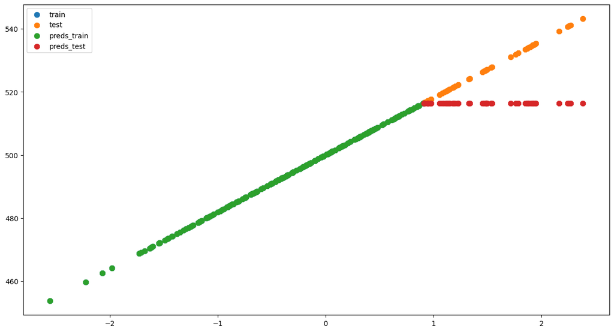

```python
# Step 5: Prediccions i representació gràfica
predictions_data_training = optimal_tree.predict(X_train)
predictions_data_testing = optimal_tree.predict(X_test)
plot_regression(X_train, y_train, X_test, y_test, preds_train=predictions_data_training, preds_test=predictions_data_testing)
```

**Anàlisi:**

1. Analitza visualment les prediccions sobre el conjunt d'entrenament. S'adapta bé el model a aquest conjunt de dades? Hi ha *overfitting*? Per què?
2. Analitza visualment les prediccions sobre el conjunt de *test*. S'adapta bé el model a aquest conjunt de dades? Per què?
3. És l'arbre de decisió un bon model per al problema que estem resolent? Per què?

En aquesta anàlisi s'ha de reflexionar sobre els resultats, justificant el comportament del model basant-se en els conceptes teòrics apresos en aquest mòdul.

Resposta:

Anàlisi punt 1 -> Es pot observar que les prediccions de les dades d'entrenament estan perfectament "casades" amb les dades d'entrenament (No es poden observar punts blaus). Aquest fet indica que el model s'ha adaptat a la perfecció a les dades d'entrenament. Si s'observen les dades de test, es pot observar que aquest ajust tan perfecte que hi ha amb les dades d'entrenament, ara, amb les dades de testing, és inexistent. Observant aquests dos fets, es pot concloure que el model pateix overffiting atès que el model és capaç de fer prediccions bones amb les dades vistes durant l'entrenament, però no és capaç de fer bones prediccions amb dades que no ha vist mai.

Anàlisi punt 2 -> Com s'ha esmentat anteriorment, les dades de test i les prediccions de test no s'ajusten, és a dir el model no és capaç de fer bones prediccions amb les dades de test, és a dir, no és capaç de fer bones prediccions amb dades que no ha vist durant el període d'entrenament perquè durant aquest ha "memoritzat" les dades.

Anàlisi punt 3 -> L'arbre de decisió no és un bon model per resoldre el problema, si ens basem en el gràfic. El model pateix overfitting i, per tant, no és fiable amb dades fora del conjunt d'entrenament. Es podria dir que l'arbre memoritza les dades, però no aprèn d'elles. A més es pot observar que a mesura que les X augmenten també ho fan les Y descrivint una línia recta homogènia (tendència lineal). Par tant, caldria trobar un altre tipus de model que fos capaç de captar aquesta tendència lineal, ja que els arbres de decisió "assumeixen" la independència de les característiques.

**Material extern consultat:**

[scikit-learn.(nd).*DecisionTreeRegressor*.scikit-learn](https://scikit-learn.org/stable/modules/generated/sklearn.tree.DecisionTreeRegressor.html)

[scikit-learn.(nd).*3.4. Metrics and scoring: quantifying the quality of predictions*.scikit-learn](https://scikit-learn.org/stable/modules/model_evaluation.html#scoring-parameter)

[scikit-learn.(nd).*r2_score*.scikit-learn](https://scikit-learn.org/stable/modules/generated/sklearn.metrics.r2_score.html#sklearn.metrics.r2_score)

[GeeksforGeeks.(15/04/2024).*Árboles de Decisión vs Algoritmos de Agrupamiento vs Regresión Lineal*.GeeksforGeeks](https://www.geeksforgeeks.org/decision-trees-vs-clustering-algorithms-vs-linear-regression/)

**Implementació:** En aquesta secció transformarem el problema per ajudar l'arbre de decisió a realitzar millors prediccions. Per fer-ho:

1. Crea un nou conjunt de dades *transformed_X_train* i *transformed_X_test* a partir dels conjunts originals *X_train* i *X_test* de manera que cada valor del conjunt transformat sigui la diferència del seu corresponent valor original (en base a la seva posició en el conjunt de dades) menys el valor previ del conjunt original. És a dir: transformed[i] = original[i] - original[i-1]. Presta especial atenció al primer valor del conjunt de dades.
2. Crea un nou conjunt de dades *transformed_y_train* i *transformed_y_test* a partir dels conjunts originals *y_train* i *y_test* aplicant la mateixa lògica del punt anterior.
3. Representa gràficament el nou problema utilitzant la funció `plot_regression`.

Amb aquesta transformació, predirem l'increment de la regressió en lloc del valor absolut.

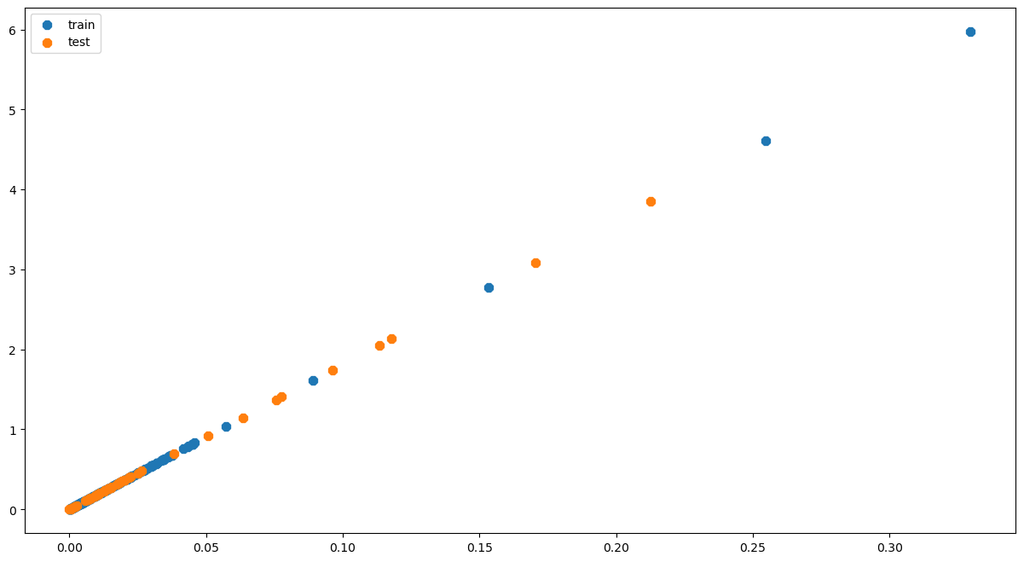

```python
# Step 1: Crear nous datasets X
transformed_X_train = np.diff(X_train, axis=0)
transformed_X_test = np.diff(X_test, axis=0)

# Step 2: Crear nous datasets Y
transformed_y_train = np.diff(y_train, axis=0)
transformed_y_test = np.diff(y_test, axis=0)

# Step 3: Representació gràfica
plot_regression(transformed_X_train, transformed_y_train, transformed_X_test, transformed_y_test)
```

**Anàlisi:** Analitza visualment el nou problema que resoldrem i justifica, basant-te en els conceptes teòrics apresos en aquest mòdul, el motiu pel qual l'arbre de decisió s'hauria d'adaptar millor a aquest problema.

Resposta:

En aquesta ocasió, es pot observar que les dades continuen descrivint una recta ascendent, però ara no és una línia homogènia com en el cas anterior sinó que hi ha "salts" (no hi ha una tendència lineal). Per tant, un arbre de decisió s'hauria d'adaptar correctament a aquest problema atès que els arbres de decisió assumeixen que les dades no tenen una relació lineal i ara podrà subdividir les dades en regions disjuntes podent aprendre d'aquests "salts".

**Material extern consultat:**

[NumPy.(nd).*numpy.diff*.NumPy](https://numpy.org/devdocs/reference/generated/numpy.diff.html)

[Vultr.(18/11/2024).*Python Numpy diff() - Calculate Discrete Differences*.Vultr](https://docs.vultr.com/python/third-party/numpy/diff)

[Varis autors.(2017).*Use np.diff but assume the input starts with an extra zero*.StackOverflow](https://stackoverflow.com/questions/41875803/use-np-diff-but-assume-the-input-starts-with-an-extra-zero)

**Implementació:** Repetirem el procés d'entrenament i predicció sobre el **nou conjunt de dades transformat**. Per fer-ho:

1. Calcula el valor òptim dels hiperparàmetres `max_depth` i `min_samples_split` per a un arbre de decisió utilitzant una cerca de reixeta amb validació creuada i la mètrica 'r2_score'. Aquest procés t'ajudarà a trobar els valors òptims que evitaran el sobreajustament.
2. Per a cada combinació de valors, calcula'n la mitjana i la desviació estàndard.
3. Mostra el valor òptim trobat per als dos hiperparàmetres.
4. Entrena un arbre de decisió amb el dataset d'entrenament (*train*) utilitzant la millor combinació de paràmetres que hagis trobat.
5. Realitza la predicció sobre el conjunt d'entrenament (*train*) i test per representar gràficament els resultats utilitzant la funció `plot_regression`. Tingues en compte que necessitem visualitzar les 4 sèries: *train*, *test*, predicció sobre *train* i predicció sobre *test*.

Utilitza el mòdul `GridSearchCV` de `sklearn` per calcular els millors hiperparàmetres amb el classificador `DecisionTreeClassifier` de `tree` de `sklearn`.

```python
# Step 1: Cerca dels millors hiperparàmetres
params = {"max_depth":list(range(1, 11)), "min_samples_split":[2, 10, 20, 50, 100]}
tree_regressor = DecisionTreeRegressor()
grid_tree = GridSearchCV(estimator=tree_regressor, param_grid=params, cv=5, scoring='r2', return_train_score=True)
grid_tree.fit(transformed_X_train, transformed_y_train) # Entrenament dels diferents models
```

```
GridSearchCV(cv=5, estimator=DecisionTreeRegressor(),
             param_grid={'max_depth': [1, 2, 3, 4, 5, 6, 7, 8, 9, 10],
                         'min_samples_split': [2, 10, 20, 50, 100]},
             return_train_score=True, scoring='r2')
```

```python
# Step 2: Resultats dels models entrenats -> Mitjanes i desviacions
df_results = pd.DataFrame(grid_tree.cv_results_) # splitX_test_score = accuracy de cada split de la grid search
df_results[["param_max_depth", "param_min_samples_split", "mean_train_score", "std_train_score", "mean_test_score", "std_test_score"]]
```

|  | param_max_depth | param_min_samples_split | mean_train_score | std_train_score | mean_test_score | std_test_score |
| --- | --- | --- | --- | --- | --- | --- |
| 0 | 1 | 2 | 0.773730 | 9.690241e-03 | -0.065084 | 0.075583 |
| 1 | 1 | 10 | 0.773730 | 9.690241e-03 | -0.065084 | 0.075583 |
| 2 | 1 | 20 | 0.773730 | 9.690241e-03 | -0.065084 | 0.075583 |
| 3 | 1 | 50 | 0.773730 | 9.690241e-03 | -0.065084 | 0.075583 |
| 4 | 1 | 100 | 0.773730 | 9.690241e-03 | -0.065084 | 0.075583 |
| 5 | 2 | 2 | 0.939160 | 6.838900e-04 | 0.576405 | 0.257491 |
| 6 | 2 | 10 | 0.888567 | 2.481098e-02 | 0.576405 | 0.257491 |
| 7 | 2 | 20 | 0.888567 | 2.481098e-02 | 0.576405 | 0.257491 |
| 8 | 2 | 50 | 0.868219 | 1.589940e-02 | 0.562666 | 0.284462 |
| 9 | 2 | 100 | 0.868219 | 1.589940e-02 | 0.562666 | 0.284462 |
| 10 | 3 | 2 | 0.982459 | 4.997939e-04 | 0.731601 | 0.313490 |
| 11 | 3 | 10 | 0.920738 | 3.075638e-02 | 0.731601 | 0.313490 |
| 12 | 3 | 20 | 0.920738 | 3.075638e-02 | 0.731601 | 0.313490 |
| 13 | 3 | 50 | 0.879970 | 1.500519e-02 | 0.684788 | 0.341155 |
| 14 | 3 | 100 | 0.877265 | 2.041550e-02 | 0.684781 | 0.341168 |
| 15 | 4 | 2 | 0.996964 | 5.369093e-04 | 0.807331 | 0.328116 |
| 16 | 4 | 10 | 0.928751 | 3.357142e-02 | 0.802147 | 0.325540 |
| 17 | 4 | 20 | 0.926982 | 3.003327e-02 | 0.793075 | 0.343683 |
| 18 | 4 | 50 | 0.880909 | 1.547495e-02 | 0.697682 | 0.347504 |
| 19 | 4 | 100 | 0.877265 | 2.041550e-02 | 0.684781 | 0.341168 |
| 20 | 5 | 2 | 0.999457 | 1.029074e-04 | 0.824395 | 0.333187 |
| 21 | 5 | 10 | 0.930267 | 3.350361e-02 | 0.817076 | 0.333020 |
| 22 | 5 | 20 | 0.927577 | 3.010034e-02 | 0.797914 | 0.346117 |
| 23 | 5 | 50 | 0.880909 | 1.547495e-02 | 0.697682 | 0.347504 |
| 24 | 5 | 100 | 0.877265 | 2.041550e-02 | 0.684781 | 0.341168 |
| 25 | 6 | 2 | 0.999899 | 1.055114e-05 | 0.829892 | 0.335921 |
| 26 | 6 | 10 | 0.930483 | 3.350482e-02 | 0.819331 | 0.334136 |
| 27 | 6 | 20 | 0.927609 | 3.008429e-02 | 0.798287 | 0.346304 |
| 28 | 6 | 50 | 0.880909 | 1.547495e-02 | 0.697682 | 0.347504 |
| 29 | 6 | 100 | 0.877265 | 2.041550e-02 | 0.684781 | 0.341168 |
| 30 | 7 | 2 | 0.999984 | 1.653374e-06 | 0.830796 | 0.336370 |
| 31 | 7 | 10 | 0.930494 | 3.350213e-02 | 0.819498 | 0.334221 |
| 32 | 7 | 20 | 0.927609 | 3.008429e-02 | 0.798287 | 0.346304 |
| 33 | 7 | 50 | 0.880909 | 1.547495e-02 | 0.697682 | 0.347504 |
| 34 | 7 | 100 | 0.877265 | 2.041550e-02 | 0.684781 | 0.341168 |
| 35 | 8 | 2 | 0.999998 | 5.007831e-07 | 0.831065 | 0.336504 |
| 36 | 8 | 10 | 0.930494 | 3.350196e-02 | 0.819500 | 0.334223 |
| 37 | 8 | 20 | 0.927609 | 3.008429e-02 | 0.798287 | 0.346304 |
| 38 | 8 | 50 | 0.880909 | 1.547495e-02 | 0.697682 | 0.347504 |
| 39 | 8 | 100 | 0.877265 | 2.041550e-02 | 0.684781 | 0.341168 |
| 40 | 9 | 2 | 1.000000 | 8.351225e-08 | 0.831111 | 0.336527 |
| 41 | 9 | 10 | 0.930494 | 3.350196e-02 | 0.819500 | 0.334223 |
| 42 | 9 | 20 | 0.927609 | 3.008429e-02 | 0.798287 | 0.346304 |
| 43 | 9 | 50 | 0.880909 | 1.547495e-02 | 0.697682 | 0.347504 |
| 44 | 9 | 100 | 0.877265 | 2.041550e-02 | 0.684781 | 0.341168 |
| 45 | 10 | 2 | 1.000000 | 6.151012e-09 | 0.831116 | 0.336530 |
| 46 | 10 | 10 | 0.930494 | 3.350196e-02 | 0.819500 | 0.334223 |
| 47 | 10 | 20 | 0.927609 | 3.008429e-02 | 0.798287 | 0.346304 |
| 48 | 10 | 50 | 0.880909 | 1.547495e-02 | 0.697682 | 0.347504 |
| 49 | 10 | 100 | 0.877265 | 2.041550e-02 | 0.684781 | 0.341168 |

```python
# Step 3: Millor combinació de paràmetres
print(grid_tree.best_params_)
```

```
{'max_depth': 10, 'min_samples_split': 2}
```

```python
# Step 4: Entrenar el millor arbre
optimal_tree = DecisionTreeRegressor(max_depth=10, min_samples_split=2)
optimal_tree.fit(transformed_X_train, transformed_y_train)
```

```
DecisionTreeRegressor(max_depth=10)
```

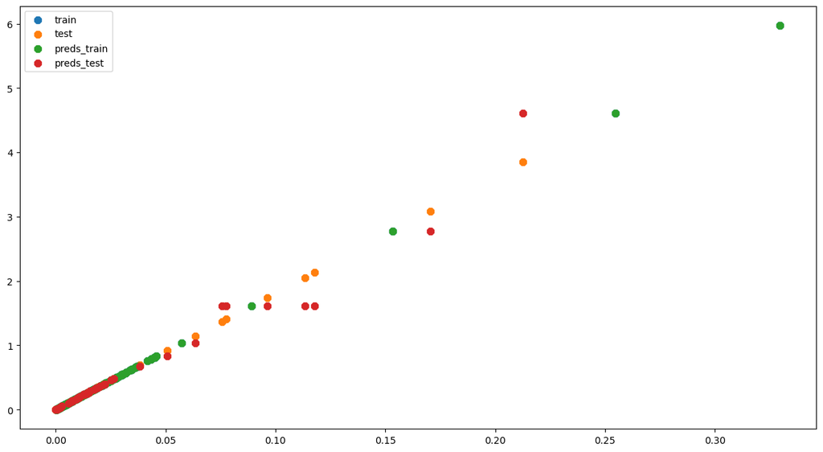

```python
# Step 5: Prediccions i representació gràfica
predictions_data_training = optimal_tree.predict(transformed_X_train)
predictions_data_testing = optimal_tree.predict(transformed_X_test)
plot_regression(transformed_X_train, transformed_y_train, transformed_X_test, transformed_y_test, preds_train=predictions_data_training, preds_test=predictions_data_testing)
```

**Anàlisi:** Analitza visualment les prediccions en el nou problema. S'adapta millor l'arbre de decisió al problema?

Resposta:

Pel que fa a les dades d'entrenament, es pot observar que els dos colors estan perfectament superposats (els uns a sobre dels altres), per tant, això significa que el model s'adapta a la perfecció a les dades d'entrenament.

Amb relació a les dades de testing, es pot observar que en la primera part del gràfic (on els punts estan més junts), la superposició és, com en el cas anterior, perfecte, però a mesura que s'avança es pot observar que els punts, taronges i vermells, es comencen a separar, és a dir, es dispersen més.

Tot i que l'arbre no s'adapta a la perfecció, sí que té un millor rendiment (si ens basem únicament en les dades que ens ofereix el gràfic) que en el cas anterior. Encara i que, el fet que l'arbre s'hagi adaptat a la perfecció a les dades d'entrenament i tingui un rendiment inferior en les dades d'entrenament, porta a continuar pensant que l'arbre de decisió pot estar patint overffiting.

**Implementació:** En aquesta secció desfarem la transformació aplicada per comprovar si el nou model resol el problema original. Per fer-ho:

1. Crea un nou conjunt de dades *original_preds_train* i *original_preds_test* a partir dels conjunts originals *preds_train* i *preds_test* desfent la transformació que hem aplicat al problema. És a dir: original[i] = original[i-1] + transformed[i]. Presta especial atenció al primer valor del conjunt de dades.
2. Representa gràficament els resultats utilitzant la funció `plot_regression`. Tingues en compte que necessitem visualitzar les 4 sèries: *train*, *test*, predicció sobre *train* i predicció sobre *test*.

```python
# Step 1: Crear nous conjunts
# Cal insertar el primer valor original perquè diff() l'ha esborrat
# Cal sumar el primer element de la sèrie original y_train[0] o y_test[0] perquè sinó només obtenim la suma acumulada
# partint desde 0 y y_train[0]/y_test[0] no son 0
original_preds_train = np.insert(y_train[0] + np.cumsum(predictions_data_training), 0, y_train[0]) #
origina_preds_test = np.insert(y_test[0] + np.cumsum(predictions_data_testing), 0, y_test[0])
```

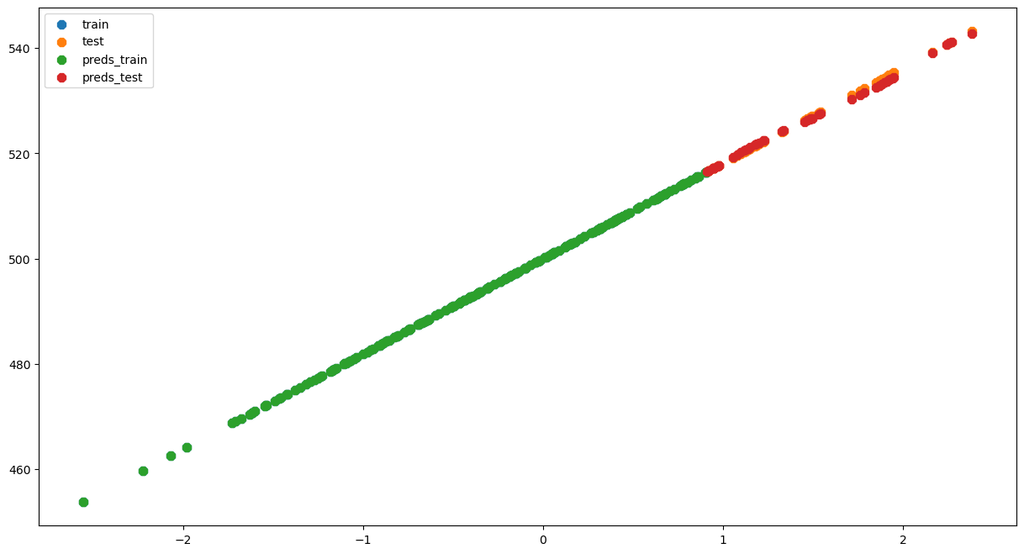

```python
# Step 2: Representació gràfica
plot_regression(X_train, y_train, X_test, y_test, preds_train=original_preds_train, preds_test=origina_preds_test)
```

**Anàlisi:** Analitza visualment les prediccions transformades al problema original. L'arbre de decisió aconsegueix resoldre el problema original? Per què? Justifica la resposta basant-te en els conceptes teòrics apresos en aquest mòdul.

Resposta:

En aquest últim gràfic s'observa que les dades d'entrenament estan completament adaptades (els punts blaus i verds s'han superposat a la perfecció). Pel que fa a les dades de test, s'observa una molt lleugera dispersió, però aquesta és tan petita, que, a priori, no fa pensar que el model pateix overfitting, tot i que el fet que les dades d'entrenament estiguin completament superposades i les dades de testing no continua essent sospitós. Caldria confirmar la sospita sobre l'overfitting amb alguna mètrica.

Observant el gràfic i amb la justificació anterior, es pot concloure que ara sí que es pot resoldre el problema.

**Material extern consultat:**

[NumPy.(nd).*numpy.cumsum*.NumPy](https://numpy.org/doc/2.1/reference/generated/numpy.cumsum.html)

[GeeksForGeeks.(04/12/2024).*numpy.cumsum() in Python*.GeeksForGeeks](https://www.geeksforgeeks.org/numpy-cumsum-in-python/)

[GeeksForGeeks.(28/03/2022).*numpy.insert() in Python*.GeeksForGeeks](https://www.geeksforgeeks.org/numpy-insert-python/)

[NumPy.(nd).*numpy.insert*.NumPy](https://numpy.org/doc/2.1/reference/generated/numpy.insert.html)

**Anàlisi:** Com es comportaria el model Knn en el problema original? Obtindria una bona predicció en el conjunt de test? Per què? Justifica la resposta basant-te en els conceptes teòrics apresos en aquest mòdul.

Resposta:

El comportament i les prediccions amb l'algorisme KNN, dependran de dues decisions molt importants. La primera és l'elecció de la mètrica de similitud, que hauria de capturar la tendència lineal (com s'ha vist anteriorment) que tenen les dades. D'acord amb el mòdul de teoria, la mètrica de similitud té una forta influència en les relacions de proximitat que es van construint en el procés de construcció de l'algorisme. La segona decisió és l'elecció del valor de K. Un valor de K massa petit podria comportar overfitting i que, per tant, el model KNN fos molt precís amb les dades d'entrenament, però que no fos capaç de generalitzar bé. Per contra, un valor massa gran de K podria comportar l'invers, el que es coneix com a underfitting. Amb un KNN amb underfitting, el model seria massa senzill i tindria un rendiment baix tant en les dades d'entrenament com en dades que no ha vist mai.

**Implementació:** Repetirem el procés d'entrenament i predicció sobre el **nou conjunt de dades transformat** aplicant el model Knn. Per fer-ho:

1. Calcula el valor òptim de l'hiperparàmetre `n_neighbors` per al regressors `KNeighborsRegressor` de `sklearn` utilitzant una cerca de reixeta amb validació creuada i la mètrica 'r2_score'.
2. Per a cada combinació de valors, calcula'n la mitjana i la desviació estàndard.
3. Mostra el valor òptim trobat per als dos hiperparàmetres.
4. Entrena un arbre de decisió amb el dataset d'entrenament (*train*) utilitzant la millor combinació de paràmetres que hagis trobat.
5. Realitza la predicció sobre el conjunt d'entrenament (*train*) i test per representar gràficament els resultats utilitzant la funció `plot_regression`. Tingues en compte que necessitem visualitzar les 4 sèries: *train*, *test*, predicció sobre *train* i predicció sobre *test*.
6. Desfés la transformació aplicada per comprovar si el nou model resol el problema original. Per fer-ho, crea un nou conjunt de dades *original_preds_train* i *original_preds_test* a partir dels conjunts originals *preds_train* i *preds_test* desfent la transformació que hem aplicat al problema. És a dir: original[i] = original[i-1] + transformed[i]. Presta especial atenció al primer valor del conjunt de dades.
7. Representa gràficament els resultats utilitzant la funció `plot_regression`. Tingues en compte que necessitem visualitzar les 4 sèries: *train*, *test*, predicció sobre *train* i predicció sobre *test*.

Utilitza el mòdul `GridSearchCV` de `sklearn` per calcular els millors hiperparàmetres amb el classificador `KNeighborsRegressor` de `neighbors` de `sklearn`.

```python
# Step 1: Valors optims
params = {"n_neighbors":list(range(1, 101))}
knn_regressor = KNeighborsRegressor()
grid_knn = GridSearchCV(estimator=knn_regressor, param_grid=params, cv=5, scoring='r2', return_train_score=True)
grid_knn.fit(transformed_X_train, transformed_y_train) # Entrenament dels diferents models

# Step 2: Mètriques
df_results = pd.DataFrame(grid_knn.cv_results_) # splitX_test_score = accuracy de cada split de la grid search
df_results[["param_n_neighbors","mean_train_score", "std_train_score", "mean_test_score", "std_test_score"]]
```

|  | param_n_neighbors | mean_train_score | std_train_score | mean_test_score | std_test_score |
| --- | --- | --- | --- | --- | --- |
| 0 | 1 | 1.000000 | 0.000000 | 0.831116 | 0.336530 |
| 1 | 2 | 0.983619 | 0.008097 | 0.829779 | 0.339239 |
| 2 | 3 | 0.957864 | 0.020794 | 0.826673 | 0.344757 |
| 3 | 4 | 0.926373 | 0.036312 | 0.824951 | 0.347655 |
| 4 | 5 | 0.874647 | 0.061980 | 0.823789 | 0.349636 |
| ... | ... | ... | ... | ... | ... |
| 95 | 96 | 0.247971 | 0.189641 | 0.535450 | 0.318234 |
| 96 | 97 | 0.244620 | 0.187737 | 0.529541 | 0.316058 |
| 97 | 98 | 0.241291 | 0.185806 | 0.522867 | 0.313527 |
| 98 | 99 | 0.238025 | 0.183906 | 0.516293 | 0.311088 |
| 99 | 100 | 0.234674 | 0.181907 | 0.509913 | 0.308689 |

100 rows × 5 columns

```python
# Step 3: Valor optim
print(grid_knn.best_params_)
```

```
{'n_neighbors': 1}
```

```python
# Step 4: Entrenament del millor model
best_knn_regressor = KNeighborsRegressor(n_neighbors=1)
best_knn_regressor.fit(transformed_X_train, transformed_y_train)
```

```
KNeighborsRegressor(n_neighbors=1)
```

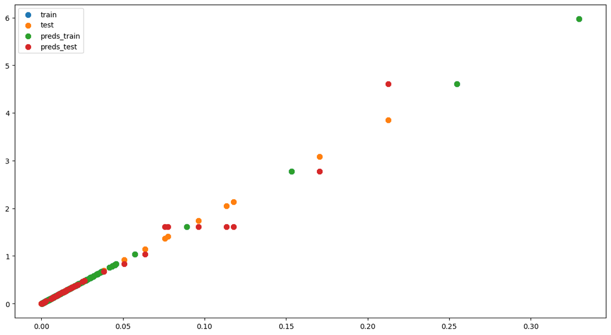

```python
# Step 5: Prediccions i representació gràfica
predictions_data_training = best_knn_regressor.predict(transformed_X_train)
predictions_data_testing = best_knn_regressor.predict(transformed_X_test)
plot_regression(transformed_X_train, transformed_y_train, transformed_X_test, transformed_y_test, preds_train=predictions_data_training, preds_test=predictions_data_testing)
```

```python
# Step 6: Crear nous conjunts
# Cal insertar el primer valor original perquè diff() l'ha esborrat
# Cal sumar el primer element de la sèrie original y_train[0] o y_test[0] perquè sinó només obtenim la suma acumulada
# partint desde 0 y y_train[0]/y_test[0] no son 0
original_preds_train = np.insert(y_train[0] + np.cumsum(predictions_data_training), 0, y_train[0]) #
origina_preds_test = np.insert(y_test[0] + np.cumsum(predictions_data_testing), 0, y_test[0])
```

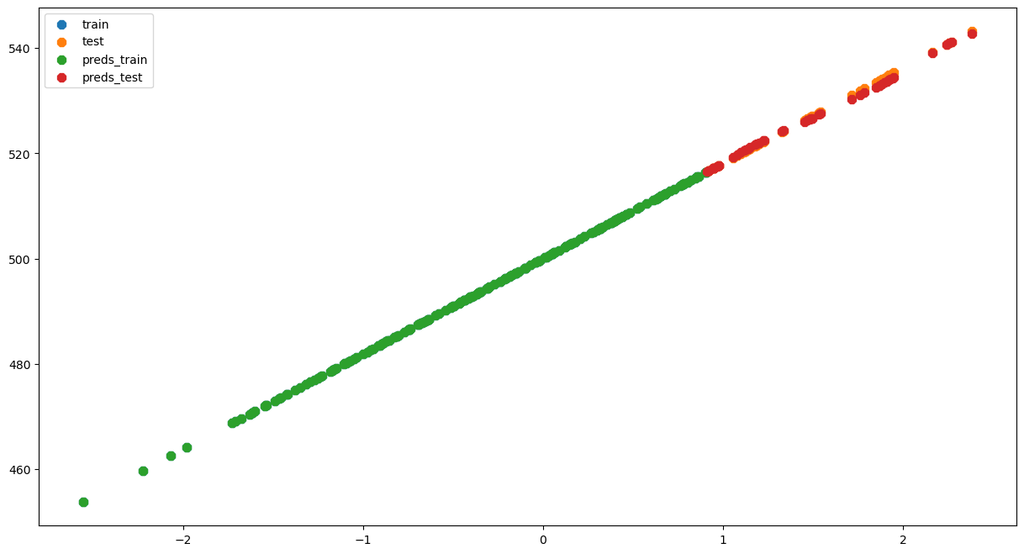

```python
# Step 7: Representació gràfica
plot_regression(X_train, y_train, X_test, y_test, preds_train=original_preds_train, preds_test=origina_preds_test)
```

**Anàlisi:** Analitza visualment les prediccions transformades al problema original. El model Knn aconsegueix resoldre el problema original? Per què? Justifica la resposta basant-te en els conceptes teòrics apresos en aquest mòdul.

Resposta:

En la representació gràfica del Step 7 de l'algorisme KNN s'observa que les dades d'entrenament estan completament solapades (tant les dades d'entrenament com les prediccions). Pel que fa a les dades de test, s'observa una dispersió molt petita que, a priori, no fa pensar que el model pateix overfitting, tot i que la superposició perfecta de les dades d'entrenament i les seves prediccions i el menor rendiment de les dades de testing continua essent un fort indicatiu de possible overfitting. Caldría comprovar la suposició amb alguna mètrica.

Observant el gràfic i amb la justificació anterior, es pot concloure que ara sí que es pot resoldre el problema.

**Material extern consultat:**

[scikit-learn.(nd).*KNeighborsRegressor*.scikit-learn](https://scikit-learn.org/stable/modules/generated/sklearn.neighbors.KNeighborsRegressor.html)

# 3. Implementació del cas pràctic (3 punts)

El sector bancari ofereix un entorn fascinant per a l'aplicació de tècniques de ciència de dades a causa de la riquesa i diversitat de les seves dades transaccionals i demogràfiques. La predicció de si un titular de préstec complirà amb els seus pagaments no només és crucial per minimitzar riscos financers, sinó també per optimitzar estratègies d'atorgament de crèdits. Aquest problema combina elements de classificació, anàlisi predictiva i detecció de patrons en grans volums de dades. A més, la implementació de models precisos pot millorar la rendibilitat de les institucions financeres i promoure un accés més just al crèdit.

Per a això, utilitzarem el conjunt de dades [bank_loan_data](https://www.kaggle.com/datasets/udaymalviya/bank-loan-data), el qual inclou dades sobre 45.000 sol·licituds de préstecs amb diversos atributs relacionats amb dades personals i els detalls del préstec. En concret, el dataset conté 14 característiques:

- person_age: Edat del sol·licitant.
- person_gender: Gènere del sol·licitant.
- person_education: Educació del sol·licitant (High School, Bachelor, Master, etc.).
- person_income: Ingressos anuals (en USD).
- person_emp_exp: Anys d'experiència laboral.
- person_home_ownership: Tipus de propietat de l'habitatge (RENT, OWN, MORTGAGE).
- loan_amnt: Quantitat del préstec sol·licitat (en USD).
- loan_intent: Propòsit del préstec (PERSONAL, EDUCATION, MEDICAL, etc.).
- loan_int_rate: Interès del préstec (percentatge).
- loan_percent_income: Proporció entre la quantitat del préstec i els ingressos.
- cb_person_cred_hist_length: Durada de l'historial creditici del sol·licitant.
- credit_score: Puntuació creditícia del sol·licitant.
- previous_loan_defaults_on_file: Indica si el sol·licitant té incompliments de préstecs previs (Yes or No).
- loan_status: variable objectiu, 1 si el préstec va ser pagat i 0 si el sol·licitant va incórrer en impagaments.

L´objectiu d´aquesta secció és abordar l´anàlisi d´aquest conjunt de dades i entrenar arbres de decisió per predir si el préstec serà pagat pel sol·licitant o incórrerà en impagaments. Aquí tens alguns passos que podries seguir:

1. **Anàlisi Exploratòria de Dades (EDA)**: Comença explorant el conjunt de dades per comprendre la seva estructura i distribució. Analitza la proporció de cada classe. Observa la distribució de les diferents característiques i la seva relació amb la classe objectiu "class".
2. **Preprocessament de Dades**: Considera normalitzar les característiques perquè estiguin a la mateixa escala que les components principals.
3. **Modelització**: Utilitza un arbre de decisió com a eina de classificació. Atès que l'objectiu és identificar el nivell de servei del lliurament, és vital centrar-se en mètriques com la precisió, la sensibilitat (recall), el valor F1 i l'àrea sota la corba ROC (AUC-ROC).
4. **Avaluació**: Realitza una avaluació i anàlisi rigorosa del rendiment del teu model.

Aquest enfocament integral us permetrà no només construir un model efectiu sinó també comprendre millor les característiques subjacents del tipus de préstec en el conjunt de dades.

## 3.1. Càrrega de dades

El primer que has de fer és carregar el conjunt de dades i visualitzar informació rellevant del mateix. Tingues en compte que en aquest exercici només utilitzarem 20000 registres del dataset. Assegura't de verificar el següent:

1. Confirma la quantitat total de files i columnes en el DataFrame.
2. Revisa el nom de cada columna del DataFrame.
3. Verifica el nombre de valors no nuls en cada columna.
4. Identifica el tipus de dades de cada columna, que pot ser int, float, object, entre altres.
5. Comprova la quantitat de memòria utilitzada pel DataFrame.

Aquests passos et proporcionaran una comprensió inicial clara i detallada del conjunt de dades amb el qual estàs treballant.

```python
# Step 0: Càrrega del dataset
root_path = kagglehub.dataset_download("udaymalviya/bank-loan-data")
dataset_path = os.path.join(root_path, "loan_data.csv")
data = pd.read_csv(dataset_path)

# Step 1: Confirmar files i columnes
data = data[:20000] # Seleccionar les primeres 20000 dades
print("---------- Step 1 ----------\n")
print(f"Nombre de columnes del dataframe: {len(data.columns)}\n")
print(f"Nombre de files del dataframe: {len(data)}\n")

# Step 2: Nom columnes
print("---------- Step 2 ----------\n")
print(f"Columnes del dataframe: \n {data.columns}\n")
print("---------- Step 3 ----------\n")
print(f"Nombre de valors no nuls per columna: \n {data.notnull().sum()}\n")
print("---------- Step 4 ----------\n")
print(f"Tipus per columna: \n {data.dtypes}")
print("---------- Step 5 ----------\n")
print(f"Memòria total usada per columna: \n {data.memory_usage(deep=True)}\n")
print(f"Memòria total usada pel dataframe: \n {data.memory_usage(deep=True).sum()} bytes\n")
```

```
---------- Step 1 ----------

Nombre de columnes del dataframe: 14

Nombre de files del dataframe: 20000

---------- Step 2 ----------

Columnes del dataframe:
 Index(['person_age', 'person_gender', 'person_education', 'person_income',
       'person_emp_exp', 'person_home_ownership', 'loan_amnt', 'loan_intent',
       'loan_int_rate', 'loan_percent_income', 'cb_person_cred_hist_length',
       'credit_score', 'previous_loan_defaults_on_file', 'loan_status'],
      dtype='object')

---------- Step 3 ----------

Nombre de valors no nuls per columna:
 person_age                        20000
person_gender                     20000
person_education                  20000
person_income                     20000
person_emp_exp                    20000
person_home_ownership             20000
loan_amnt                         20000
loan_intent                       20000
loan_int_rate                     20000
loan_percent_income               20000
cb_person_cred_hist_length        20000
credit_score                      20000
previous_loan_defaults_on_file    20000
loan_status                       20000
dtype: int64

---------- Step 4 ----------

Tipus per columna:
 person_age                        float64
person_gender                      object
person_education                   object
```

[output cut: 19 more lines]

```
person_income                      160000
person_emp_exp                     160000
person_home_ownership             1248792
loan_amnt                          160000
loan_intent                       1339520
loan_int_rate                      160000
loan_percent_income                160000
cb_person_cred_hist_length         160000
credit_score                       160000
previous_loan_defaults_on_file    1190127
loan_status                        160000
dtype: int64

Memòria total usada pel dataframe:
 7771797 bytes
```

**Material extern consultat:**

[Pnadas.(nd).*pandas.notnull*.Pandas](https://pandas.pydata.org/docs/reference/api/pandas.notnull.html)

[Pnadas.(nd).*pandas.DataFrame.dtypes*.Pandas](https://pandas.pydata.org/docs/reference/api/pandas.DataFrame.dtypes.html)

[Pnadas.(nd).*pandas.DataFrame.memory_usage*.Pandas](https://pandas.pydata.org/docs/reference/api/pandas.DataFrame.memory_usage.html)

## 3.2. Anàlisi Exploratòria de Dades (EDA) (1 punt)

L'Anàlisi Exploratòria de Dades (EDA, per les seves sigles en anglès) en ciència de dades és un enfocament inicial per comprendre i resumir el contingut d'un conjunt de dades. Aquest procés implica diverses tècniques i passos:

1. **Inspecció de Dades**: Es comença per revisar les dades brutes per identificar-ne l'estructura, la mida i el tipus (com a numèric, categòric). Això inclou detectar valors faltants o inusuals.
2. **Resum Estadístic**: Es calculen estadístiques descriptives com la mitjana, la mediana, el rang, la variància i la desviació estàndard per obtenir una idea general de les tendències i els patrons en les dades.
3. **Visualització de Dades**: S'utilitzen gràfics i diagrames (com ara histogrames, gràfics de caixa, diagrames de dispersió) per visualitzar distribucions, relacions entre variables i possibles anomalies. Això ajuda a comprendre millor les dades i a identificar patrons o irregularitats.
4. **Anàlisi de Relacions i Correlacions**: S'exploren les relacions entre diferents variables per entendre com s'influencien entre si. Això pot implicar l'ús de matrius de correlació i gràfics de dispersió.
5. **Identificació de Patrons i Anomalies**: Es busquen patrons consistents o anomalies (com ara valors atípics) que puguin suggerir tendències o problemes en les dades.

L'EDA és una fase crítica en qualsevol projecte de ciència de dades, ja que proporciona una comprensió profunda i una base sòlida per a posteriors anàlisis i modelatge.

**Implementació:**

1. Calcula les freqüències de la variable objectiu (`loan_status`) en el teu conjunt de dades.
2. Crea un gràfic de barres per visualitzar aquestes freqüències. Això t'ajudarà a entendre la proporció dels préstecs rendibles per al banc en comparació amb els que incorren en impagaments.

A continuació, analitza la distribució de les variables numèriques:

1. Representa gràficament l'histograma de les variables, separant les observacions segons la classe a la qual pertanyen.
2. Organitza tots els histogrames en un format de 4 files i 2 columnes. Això facilitarà la comparació visual de les distribucions per a cada classe en cada variable.

Finalment, analitza la distribució de les variables categòriques de forma anàloga a les variables numèriques, organitzant tots els histogrames en un format de 3 files i 2 columnes.

Aquests passos et permetran obtenir una visió més clara de l'estructura del teu conjunt de dades i com les diferents variables poden influir en la identificació dels impagaments.

```python
# Step 1: Comptar freqüències variable objectiu
frequencies = data['loan_status'].value_counts()
frequencies
```

```
loan_status
0    15279
1     4721
Name: count, dtype: int64
```

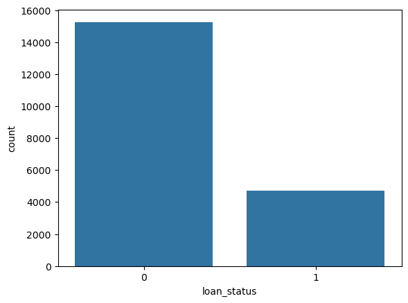

```python
# Step 2: Gràfic de barres amb les frequüències
plt.figure()
sns.barplot(frequencies)
plt.show()
```

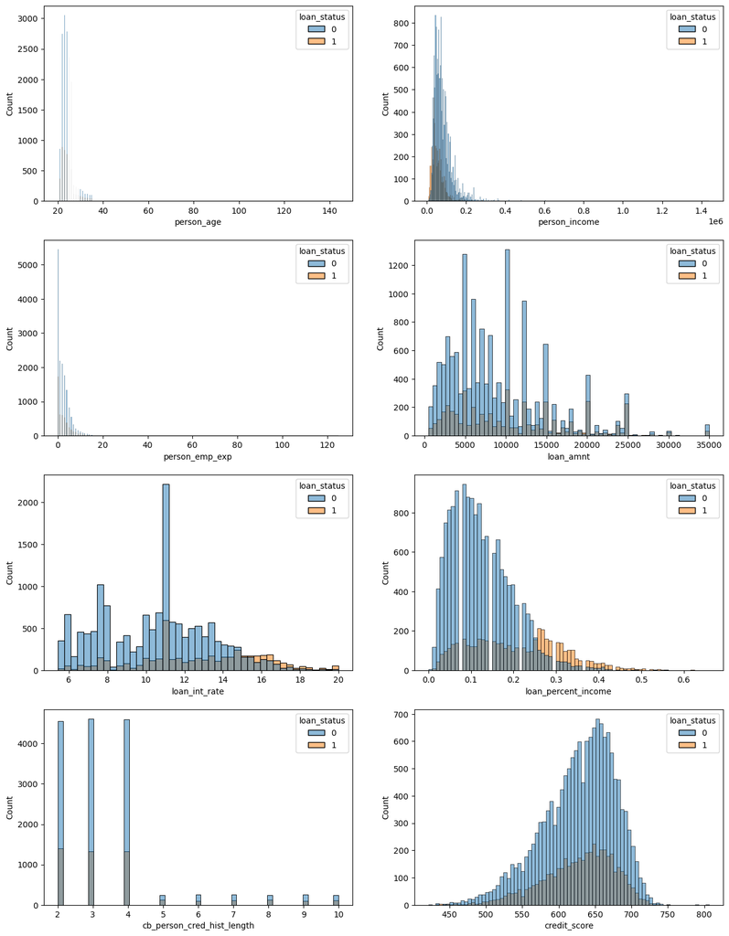

```python
# Step 3: Histogrames de les variables numèriques
variables_num = ["person_age", "person_income", "person_emp_exp", "loan_amnt", "loan_int_rate", "loan_percent_income",
                 "cb_person_cred_hist_length", "credit_score"]
plt.figure(figsize=(15, 20))
i = 1
for column in variables_num:
    plt.subplot(4, 2, i) # El tercer paràmetre es la posició de cada gràfic
    sns.histplot(data=data, x=column, hue='loan_status') # hue -> Per separar segons el valor de la classe objectiu com s'indica al principi
    i += 1
plt.show()
```

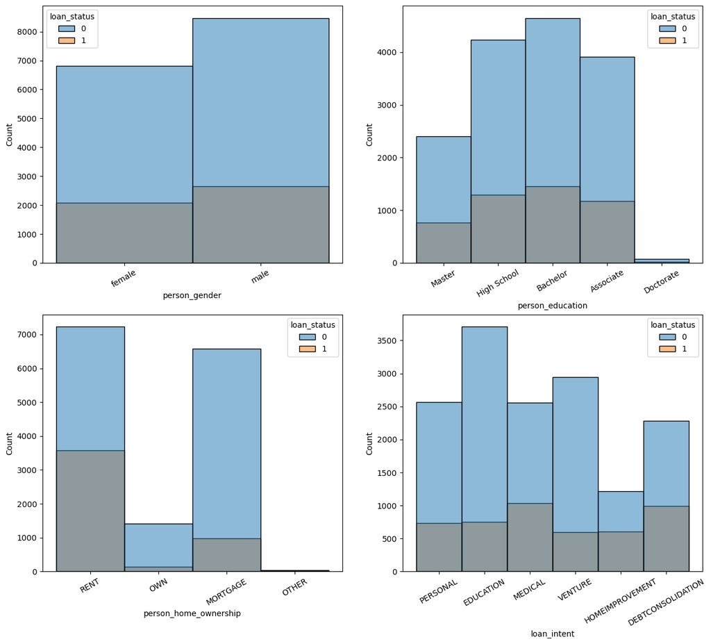

```python
# Step 4: Histogrames variables categòriques
variables_cat = ["person_gender", "person_education", "person_home_ownership", "loan_intent"]
plt.figure(figsize=(15, 20))
i = 1
for column in variables_cat:
    plt.subplot(3, 2, i) # El tercer paràmetre es la posició de cada gràfic
    sns.histplot(data=data, x=column, hue='loan_status') # hue -> Per separar segons el valor de la classe objectiu com s'indica al principi
    plt.xticks(rotation=30)
    i += 1
plt.show()
```

**Material extern consultat:**

[Pandas.(nd).*pandas.Series.value_counts*.Pandas](https://pandas.pydata.org/docs/reference/api/pandas.Series.value_counts.html)

[Seaborn.(nd).*seaborn.barplot*.Seaborn](https://seaborn.pydata.org/generated/seaborn.barplot.html)

[Seaborn.(nd).*seaborn.histplot*.Seaborn](https://seaborn.pydata.org/generated/seaborn.histplot.html)

[Austin Chia.(11/01/2024).*How to Make a Seaborn Histogram: A Detailed Guide*.Data Camp](https://www.datacamp.com/tutorial/how-to-make-a-seaborn-histogram)

[matplotlib.(nd).*matplotlib.pyplot.subplot*.matplotlib](https://matplotlib.org/stable/api/_as_gen/matplotlib.pyplot.subplot.html)

**Anàlisi:**

1. Avalua la relació de les freqüències de la variable `loan_status`. Reflexiona sobre com es distribueixen els préstecs rendibles i els que incorren en impagaments. És la distribució significativament desigual? Què implica això per a l'anàlisi i la modelització de les dades?
2. Analitza la informació proporcionada pels histogrames de les variables descriptores. Observa si hi ha diferències notables en les distribucions d'aquestes variables entre les classes. Pregunta't: Hi ha variables que mostrin patrons distints per a l'estat del préstec?
3. Considera si hi ha altres formes de visualització que podrien ser útils per entendre millor les dades. Per exemple, serien útils els diagrames de caixa (*boxplots*) per visualitzar la distribució de les variables en ambdues classes? Podria un mapa de calor de la matriu de correlació entre variables ajudar-te a entendre les relacions entre elles?

Aquesta anàlisi t'ajudarà a obtenir una comprensió més profunda de la naturalesa de les teves dades i a identificar possibles característiques que podrien ser importants per detectar els préstecs rendibles.

Resposta:

Anàlisi punt 1 -> Analitzant el gràfic de les freqüències de loan_status, s'observa un clar desequilibri en les freqüències atès que hi ha una quantitat molt major de loan_status = 0 que de loan_status = 1. Això podria comportar problemes per als models, ja que es podrien veure esbiaixats cap a la classe de la qual es disposa més dades. En aquest cas loan_status = 0 (inpagaments).

Anàlisi punt 2 -> En el cas de les variables categòriques es confirma l'observat en el càlcul de freqüències de la variable objectiu. És a dir, totes les variables categòriques mostren clarament, que per totes elles, hi ha major nombre de crèdits amb impagaments. Pel que fa a les variables numèriques, es poden observar el següent: Per les variables person_age, person_emp_exp, credit_score i cb_person_cred_hist_length es confirma el que s'observa en el càlcul de freqüències. Hi ha més crèdits amb impagaments que crèdits pagats. La variable loan_amnt, tot i tenir un major nombre de crèdits pagats en algun moment, no trenca el patró de tenir més impagaments que pagaments exitosos. La variable person_income, mostra com a mesura que augmenten els ingressos augmenten els impagaments. Les variables loan_int_rate i loan_percent mostren clarament que a mesura que aquestes augmenten també augmenten el nombre de crèdits pagats exitosament, fins a superar el nombre de crèdits amb impagaments.

Anàlisi punt 3 -> Els diagrames de caixa serien una bona opció per observar la distribució de crèdits amb impagaments i crèdits pagats exitosament. Amb aquests tipus de gràfic es podria veure de manera molt senzilla, i per cada variable descriptiva, com es relacionen amb el valor de la variable objectiu. El mapa de calor també seria una bona opció, ja que ens permetria identificar quines són les variables descriptives que més informació aporten a la variable objectiu.

## 3.3. Preprocessament de Dades (0.75 punts)

El preprocessament de dades en ciència de dades és un pas crucial que involucra la preparació i transformació de dades brutes en un format adequat per a la seva posterior anàlisi i modelatge. Aquest procés inclou diverses tasques essencials:

1. **Neteja de Dades**: S'eliminen o es corregeixen dades errònies, incompletes, inexactes o irrellevants. Això pot incloure tractar amb valors faltants, corregir errors d'entrada i gestionar *outliers*.
2. **Normalització i Escalada**: Les dades es transformen perquè estiguin en una escala comuna, sense distorsionar diferències en els rangs de valors ni perdre informació. Per exemple, escalat min-max o estandardització.
3. **Codificació de Variables Categòriques**: Les variables categòriques (com ara gènere o país) es converteixen en formats numèrics perquè puguin ser processades per algoritmes d'aprenentatge automàtic, utilitzant tècniques com la codificació *one-hot* o la codificació d'etiquetes.
4. **Divisió de Dades**: Les dades es divideixen en conjunts d'entrenament, validació i prova, permetent entrenar models, afinar hiperparàmetres i avaluar el rendiment del model de manera efectiva.
5. **Gestió de Dades Desbalancejades**: En casos de conjunts de dades desbalancejats, s'apliquen tècniques com el sobremostreig o el submostreig per assegurar que el model no estigui biaixat cap a la classe més freqüent.
6. **Enginyeria de Característiques**: Es creen noves variables (característiques) a partir de les dades existents per millorar la capacitat del model per aprendre patrons i fer prediccions.

El preprocessament és essencial per millorar la qualitat de les dades i fer-les més adequades i efectives per a l'anàlisi i el modelatge en projectes de ciència de dades.

**Implementació:** elimina els atributs categòrics del conjunt de dades i, en el seu lloc, introdueix la transformació d'aquests atributs a tantes variables binàries com categories tinguin. És important que les noves columnes generades siguin de tipus enter. Recorda que la codificació *one-hot* converteix les etiquetes categòriques en vectors binaris. En aquests vectors, el valor d'1 s'assigna a la posició corresponent a la classe i el valor de 0 a totes les altres posicions. Això facilita que els models d'aprenentatge automàtic processin i entenguin les etiquetes categòriques.

Suggeriment: utilitzeu la funció "get\_dummies" de "pandas".

```python
cat_cols = ["person_gender", "person_education", "person_home_ownership", "loan_intent", "previous_loan_defaults_on_file"]
data_one_hot = pd.get_dummies(data, columns=cat_cols, drop_first=False, dtype=int)
data_one_hot.head()
```

|  | person_age | person_income | person_emp_exp | loan_amnt | loan_int_rate | loan_percent_income | cb_person_cred_hist_length | credit_score | loan_status | person_gender_female | ... | person_home_ownership_OWN | person_home_ownership_RENT | loan_intent_DEBTCONSOLIDATION | loan_intent_EDUCATION | loan_intent_HOMEIMPROVEMENT | loan_intent_MEDICAL | loan_intent_PERSONAL | loan_intent_VENTURE | previous_loan_defaults_on_file_No | previous_loan_defaults_on_file_Yes |
| --- | --- | --- | --- | --- | --- | --- | --- | --- | --- | --- | --- | --- | --- | --- | --- | --- | --- | --- | --- | --- | --- |
| 0 | 22.0 | 71948.0 | 0 | 35000.0 | 16.02 | 0.49 | 3.0 | 561 | 1 | 1 | ... | 0 | 1 | 0 | 0 | 0 | 0 | 1 | 0 | 1 | 0 |
| 1 | 21.0 | 12282.0 | 0 | 1000.0 | 11.14 | 0.08 | 2.0 | 504 | 0 | 1 | ... | 1 | 0 | 0 | 1 | 0 | 0 | 0 | 0 | 0 | 1 |
| 2 | 25.0 | 12438.0 | 3 | 5500.0 | 12.87 | 0.44 | 3.0 | 635 | 1 | 1 | ... | 0 | 0 | 0 | 0 | 0 | 1 | 0 | 0 | 1 | 0 |
| 3 | 23.0 | 79753.0 | 0 | 35000.0 | 15.23 | 0.44 | 2.0 | 675 | 1 | 1 | ... | 0 | 1 | 0 | 0 | 0 | 1 | 0 | 0 | 1 | 0 |
| 4 | 24.0 | 66135.0 | 1 | 35000.0 | 14.27 | 0.53 | 4.0 | 586 | 1 | 0 | ... | 0 | 1 | 0 | 0 | 0 | 1 | 0 | 0 | 1 | 0 |

5 rows × 28 columns

```python
print(f"Tipus per columna: \n {data_one_hot.dtypes}")
```

```
Tipus per columna:
 person_age                            float64
person_income                         float64
person_emp_exp                          int64
loan_amnt                             float64
loan_int_rate                         float64
loan_percent_income                   float64
cb_person_cred_hist_length            float64
credit_score                            int64
loan_status                             int64
person_gender_female                    int64
person_gender_male                      int64
person_education_Associate              int64
person_education_Bachelor               int64
person_education_Doctorate              int64
person_education_High School            int64
person_education_Master                 int64
person_home_ownership_MORTGAGE          int64
person_home_ownership_OTHER             int64
person_home_ownership_OWN               int64
person_home_ownership_RENT              int64
loan_intent_DEBTCONSOLIDATION           int64
loan_intent_EDUCATION                   int64
loan_intent_HOMEIMPROVEMENT             int64
loan_intent_MEDICAL                     int64
loan_intent_PERSONAL                    int64
loan_intent_VENTURE                     int64
previous_loan_defaults_on_file_No       int64
previous_loan_defaults_on_file_Yes      int64
dtype: object
```

**Implementació:**

Ara realitzarem la divisió del conjunt de dades. Per fer-ho, segueix aquests passos:

1. Separa els descriptors de la variable resposta. Assigna els descriptors al conjunt `X` i la variable resposta al conjunt `y`.
2. Divideix el *dataset* en dos subconjunts: un per a entrenament (*train*) i un altre per a proves (*test*). Assigna el 80% de les dades al conjunt d'entrenament (`X_train`, `y_train`) i el 20% al conjunt de proves (`X_test`, `y_test`). Utilitza la funció `train_test_split` de la biblioteca `model_selection` de `sklearn`. Assegura't d'utilitzar `random_state = 24` i fes una divisió estratificada per mantenir la mateixa proporció de classes en ambdós conjunts.

```python
X = data_one_hot.drop(columns=['loan_status'])
y = data_one_hot['loan_status']
X_train, X_test, y_train, y_test = train_test_split(
    X, y, test_size=0.2, random_state=24 # 0.2 = 20% per a test -> 0.8 = 80% per a train
    , stratify=y
)
```

**Implementació:**

1. Normalitza els descriptors utilitzant l'`StandardScaler` d'`sklearn`. Això estandarditzarà les característiques restant la mitjana i dividint per la desviació estàndard.
2. Mostra les dimensions del conjunt de descriptors original, del conjunt d'entrenament i del conjunt de prova. Això et permetrà veure com s'han dividit les dades.

**Nota:** Ajusta l'`StandardScaler` únicament amb els descriptors d'entrenament per evitar la fuga d'informació o '*data leakage*'. La fuga d'informació ocorre quan s'utilitza informació del conjunt de prova o validació en el procés d'ajust del model. És a dir, si ajustes el model d'escalat amb tot el conjunt de dades, estaries utilitzant informació del conjunt de prova o validació en l'ajust, la qual cosa podria donar la impressió que el model és més precís del que realment és. Per tant, assegura't d'ajustar l'`StandardScaler` només amb les dades d'entrenament i després aplicar-lo als conjunts d'entrenament i prova.

```python
# Step 1: Normalitzar
scaler = StandardScaler()
X_train_normalized = scaler.fit_transform(X_train) # Ajustar (entrenar) scaler a les dades de train i normalitzar
X_test_normalized = scaler.transform(X_test) # Normalitzar dades de test

# Step 2: Mostrar dimensions
print(f"Dimensions conjunt original: {X.shape}")
print(f"Dimensions conjunt entrenament: {X_train.shape}")
print(f"Dimensions conjunt test: {X_test.shape}")
print(f"Dimensions conjunt entrenament normalitzat: {X_train_normalized.shape}")
print(f"Dimensions conjunt test normalitzat: {X_test_normalized.shape}")
```

```
Dimensions conjunt original: (20000, 27)
Dimensions conjunt entrenament: (16000, 27)
Dimensions conjunt test: (4000, 27)
Dimensions conjunt entrenament normalitzat: (16000, 27)
Dimensions conjunt test normalitzat: (4000, 27)
```

**Material extern consultat:**

[Pandas.(nd).*pandas.get_dummies*.Pandas](https://pandas.pydata.org/docs/reference/api/pandas.get_dummies.html)

[scikit-learn.(nd).*train_test_split*.scikit-learn](https://scikit-learn.org/stable/modules/generated/sklearn.model_selection.train_test_split.html)

[Diversos autors.(diverses dates).*Parameter "stratify" from method "train_test_split" (scikit Learn)*.StackOverflow](https://stackoverflow.com/questions/34842405/parameter-stratify-from-method-train-test-split-scikit-learn)

[Pandas.(nd).*pandas.DataFrame.drop*.Pandas](https://pandas.pydata.org/docs/reference/api/pandas.DataFrame.drop.html)

[scikit-learn.(nd).*StandardScaler*.scikit-learn](https://scikit-learn.org/stable/modules/generated/sklearn.preprocessing.StandardScaler.html)

## 3.4. Modelització (1.25 punts)

La modelització és una fase crucial en què hem de prendre moltes decisions i ser molt rigorosos amb la metodologia. Diversos dels punts clau en aquesta fase són els següents:

- **Selecció i configuració del model**: Triar l'algoritme de classificació més adequat segons el problema, les dades i els objectius (per exemple, SVM, arbres de decisió, etc.), definint també els criteris d'avaluació.
- **Entrenament i ajust d'hiperparàmetres**: Entrenar el model amb les dades disponibles i realitzar una cerca d'hiperparàmetres (*grid search*, *random search* o tècniques bayesianes).
- **Avaluació i validació del model**: Mesurar el rendiment del model amb mètriques adequades (precisió, *recall*, *F1-score*, AUC, etc.) i validar el seu comportament amb tècniques com la validació creuada.
- **Explicabilitat del model**: Analitzar i interpretar com i per què el model pren decisions, utilitzant eines com coeficients, SHAP, LIME o visualització de vectors de suport, per assegurar transparència i confiança en l'ús del model.

**Implementació:** Aquest exercici l'abordarem utilitzant un model d'arbre de decisió. Per fer-ho:

1. Defineix un classificador `DecisionTreeClassifier` de la biblioteca `tree` d'`sklearn` sense especificar cap paràmetre i calcula la seva precisió sobre el conjunt d'entrenament aplicant validació creuada amb 5 conjunts.
2. Entrena un nou model sobre el conjunt de dades d'entrenament.
3. Calcula les mètriques següents tant en les dades d'entrenament (*train*) com de prova (*test*):
   - Calcula l'exactitud (*accuracy*) per mesurar la correcció de les prediccions.
   - Calcula el valor F1, que és una mesura que combina precisió i sensibilitat.
4. Calcula la matriu de confusió utilitzant les dades de prova (*test*).

Utiliza el módulo `cross_val_score` de `sklearn` para aplicar la validación cruzada con el clasificador DecisionTree (de `DecisionTreeClassifier` de `sklearn`).

```python
# Step 1: Crear l'arbre classificador sense paràmetres
tree_classifier = DecisionTreeClassifier()
cross_validation = cross_val_score(tree_classifier, X_train_normalized, y_train, cv=5, scoring="accuracy")
cross_validation
```

```
array([0.886875 , 0.904375 , 0.89625  , 0.8828125, 0.8953125])
```

```python
# Step 2: Entrenar nou arbre amb dades
tree_classifier = DecisionTreeClassifier()
tree_classifier.fit(X_train_normalized, y_train)

# Step 3: Mètriques
# Step 3.1: Accuracy
predictions_data_training = tree_classifier.predict(X_train_normalized) # Prediccions amb dades d'entrenament
predictions_data_testing = tree_classifier.predict(X_test_normalized) # Predeiccions amb dades de testing
training_accuracy = accuracy_score(y_train, predictions_data_training)
testing_accuracy = accuracy_score(y_test, predictions_data_testing)
print(f"Accuracy dades entrenament: {training_accuracy}\n")
print(f"Accuracy dades testing: {testing_accuracy}")

# Step 3.2: F1 score
f1_data_training = f1_score(y_train, predictions_data_training)
f1_data_testing = f1_score(y_test, predictions_data_testing)
print(f"F1 dades entrenament: {f1_data_training}\n")
print(f"F1 dades testing: {f1_data_testing}")
```

```
Accuracy dades entrenament: 1.0

Accuracy dades testing: 0.893
F1 dades entrenament: 1.0

F1 dades testing: 0.7733050847457628
```

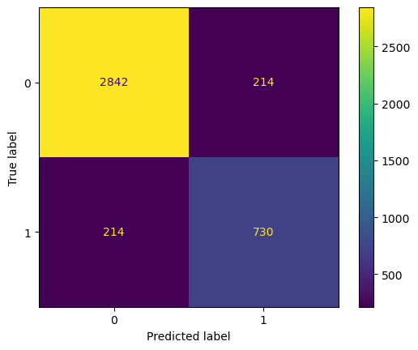

```python
# Step 4: Matriu de confusió
from sklearn.metrics import ConfusionMatrixDisplay
conf_mat = confusion_matrix(y_test, predictions_data_testing)
conf_mat_display = ConfusionMatrixDisplay(confusion_matrix=conf_mat) # Per veure la matriu de confusió bonica
conf_mat_display.plot()
plt.show()
```

True positive rate -> Quan realment és "sí", quants cops el model prediu "sí"?

True negative_rate -> Quan realment és "no", quants cops el model prediu "no"?

True positive rate = True positive / actual yes = 730 / (730 + 214) = 77.33%

Amb els resultats de la matriu s'observa que el model és millor predient quan loan_status = 0, és a dir quan hi ha impagaments.

**Anàlisi:**

1. Realitza una anàlisi dels resultats i decideix si consideres que aquest model és acceptable.
2. Avalua quina de les mesures de rendiment utilitzades és la més apropiada.
3. Examina la distribució de les classes i planteja una estratègia, si és necessari, per assegurar la fiabilitat de l'estudi realitzat.

Resposta:

Analàlisi punt 1 -> S'observa que l'arbre té una precisió i una F1 perfecta (100%) en les dades d'entrenament, fet que és un indici molt fort de què l'arbre pareix overfitting. Aquestes sospites es confirmen en observar la accuracy i l'F1 de les dades de test. En el cas de l'accuracy l'arbre té un 89% i en el cas de l'F1 un 77%. Amb aquestes dades es pot concloure que l'arbre ha memoritzat les dades d'entrenament, però no sap actuar amb dades que no ha vist mai. En la matriu de confusió es pot observar que l'arbre és millor predient quan els préstecs tenen impagaments (loan_status = 0).

Pel que fa a l'arbre sense paràmetres especificats (el primer) i cross_val_score es poden observar unes accuracy d'entre 88% i 90%. Aquesta poca variabilitat i el fet que no hi hagi puntuacions del 100% donen confiança en el model.

Anàlisi punt 3 -> Donat el desequilibri en la variable objectiu (hi ha molts més loan_status = 0 que loan_status = 1), és necessari aplicar una tècnica per equilibrar les classes. Després de repassar el document "Preparació de les mostres" del bloc 1 de l'assignatura, l'estratègia que es planteja per millorar la fiabilitat de l'estudi és SMOTE. Aquesta tècnica genera elements sintètics de la classe minoritària a partir dels elements disponibles.

**Material extern consultat:**

[scikit-learn.(nd).*DecisionTreeClassifier*.scikit-learn](https://scikit-learn.org/stable/modules/generated/sklearn.tree.DecisionTreeClassifier.html)

[scikit-learn.(nd).*cross_val_score*.scikit-learn](https://scikit-learn.org/stable/modules/generated/sklearn.model_selection.cross_val_score.html)

[scikit-learn.(nd).*f1_score*.scikit-learn](https://scikit-learn.org/stable/modules/generated/sklearn.metrics.f1_score.html)

[Puirva Huilgol.(24/08/2019).*Accuracy vs. F1-Score*.Medium](https://medium.com/analytics-vidhya/accuracy-vs-f1-score-6258237beca2)

[Diversos autors.(diverses dates).*F1 score vs accuracy, which metric is more important?*.DataSciene](https://datascience.stackexchange.com/questions/65341/f1-score-vs-accuracy-which-metric-is-more-important)

**Implementació:** Repeteix el procediment anterior considerant l'estratègia que consideris necessària per millorar la fiabilitat del model.

**Degut a la impossibilitat de trobar una versio de imb-learn compatible amb la versió 1.5.1 de scikit learn que té l'entorn, no ha estat possible implementar aques última part.**

**Implementació:** Els arbres de decisió ens permeten calcular la contribució relativa de cada atribut descriptiu al rendiment predictiu del model. Per fer-ho,

1. Calcula la contribució relativa de cada atribut utilitzant l'atribut `feature_importances_`.
2. Crea un DataFrame que contingui dues columnes: el nom de l'atribut descriptiu i la seva contribució.
3. Ordena les files pel valor de contribució.
4. Mostra el DataFrame resultant.

**Anàlisi:**

Relaciona la interpretació de la contribució dels atributs descriptius amb l'anàlisi exploratòria de les dades realitzada a l'exercici 3.2.